# MultiNicheNet analysis: anti-PD1 Breast cancer multifactorial comparison - step-by-step with all details

## Step 0.3: Prepare settings of the MultiNicheNet cell-cell communication analysis

### Define in which metadata columns we can find the **group**, **sample** and **cell type** IDs

If you would have batch effects or covariates you can correct for, you can define this here as well.

Important: for categorical covariates and batches, there should be at least one sample for every group-batch combination. If one of your groups/conditions lacks a certain level of your batch, you won’t be able to correct for the batch effect because the model is then not able to distinguish batch from group/condition effects.

Important: the column names of group, sample, cell type, batches and covariates should be syntactically valid (`make.names`)

Important: All group, sample, cell type, batch and covariate names should be syntactically valid as well (`make.names`) (eg through `SummarizedExperiment::colData(sce)$ShortID = SummarizedExperiment::colData(sce)$ShortID %>% make.names()`)

```r
sample_id = "sample_id"
group_id = "expansion_timepoint"
celltype_id = "subType"
covariates = NA
batches = NA
```

Sender and receiver cell types also need to be defined. Both are here all cell types in the dataset because we are interested in an All-vs-All analysis.

```r
senders_oi = SummarizedExperiment::colData(sce)[,celltype_id] %>% unique()
receivers_oi = SummarizedExperiment::colData(sce)[,celltype_id] %>% unique()
```

If the user wants it, it is possible to use only a subset of senders and receivers. Senders and receivers can be entirely different, but also overlapping, or the same. If you don’t use all the cell types in your data, we recommend to continue with a subset of your data.

```r
sce = sce[, SummarizedExperiment::colData(sce)[,celltype_id] %in% c(senders_oi, receivers_oi)]
```

Now we will go to the first real step of the MultiNicheNet analysis

# Step 1: Extract cell type abundance and expression information from receiver and sender cell types, and link this expression information for ligands of the sender cell types to the corresponding receptors of the receiver cell types

Since MultiNicheNet will infer group differences at the sample level for each cell type (currently via Muscat - pseudobulking + EdgeR), we need to have sufficient cells per sample of a cell type, and this for both groups. In the following analysis we will set this minimum number of cells per cell type per sample at 10 (recommended minimum).

```r
min_cells = 10
```

Now we will calculate abundance and expression information for each cell type / sample / group combination with the following functions. In the output of this function, you can also find some ‘Cell type abundance diagnostic plots’ that will the users which celltype-sample combinations will be left out later on for DE calculation because the nr of cells is lower than de defined minimum defined here above. If too many celltype-sample combinations don’t pass this threshold, we recommend to define your cell types in a more general way (use one level higher of the cell type ontology hierarchy) (eg TH17 CD4T cells –> CD4T cells).

```r
abundance_expression_info = get_abundance_expression_info(sce = sce, sample_id = sample_id, group_id = group_id, celltype_id = celltype_id, min_cells = min_cells, senders_oi = senders_oi, receivers_oi = receivers_oi, lr_network = lr_network, batches = batches)
```

First, we will check the cell type abundance diagnostic plots.

### Interpretation of cell type abundance information

The first plot visualizes the number of cells per celltype-sample combination, and indicates which combinations are removed during the DE analysis because there are less than `min_cells` in the celltype-sample combination.

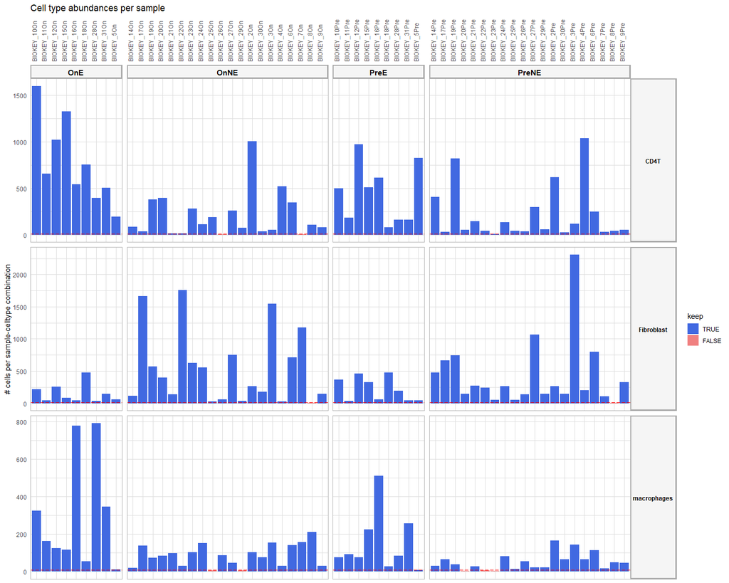

```r
abundance_expression_info$abund_plot_sample
```

The red dotted line indicates the required minimum of cells as defined above in `min_cells`. We can see here that some sample-celltype combinations are left out. For the DE analysis in the next step, only cell types will be considered if there are at least two samples per group with a sufficient number of cells.

In a next plot, we will look at differential abundance between the conditions. This because the pseudobulking approach behind Muscat could potentially suffer from some biases if there would be huge differences in abundances of a cell type between different groups. Downstream results of these cell types should then be considered with some caution.

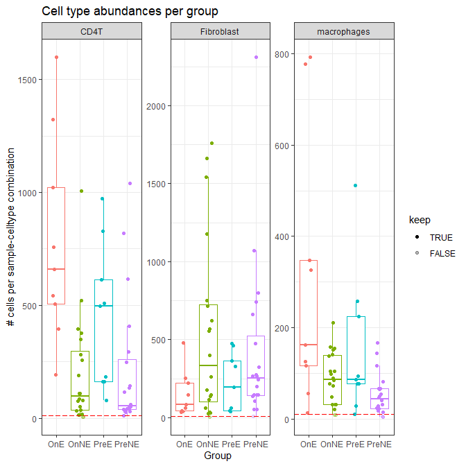

```r
abundance_expression_info$abund_plot_group
```

Differential abundance looks quite OK.

If you want to look at the cell numbers behind these plots, you can do so via the following piece of code

```r
abundance_expression_info$abundance_data_receiver %>% head()
## # A tibble: 6 x 5
## # Groups:   sample, receiver [6]
##   sample       receiver    n_cells_receiver group keep_receiver
##   <chr>        <chr>                  <int> <chr>         <dbl>
## 1 BIOKEY_10On  CD4T                    1600 OnE               1
## 2 BIOKEY_10On  Fibroblast               220 OnE               1
## 3 BIOKEY_10On  macrophages              326 OnE               1
## 4 BIOKEY_10Pre CD4T                     497 PreE              1
## 5 BIOKEY_10Pre Fibroblast               365 PreE              1
## 6 BIOKEY_10Pre macrophages               77 PreE              1
abundance_expression_info$abundance_data_sender %>% head() # in the case of an all-vs-all analysis: both are the same
## # A tibble: 6 x 5
## # Groups:   sample, sender [6]
##   sample       sender      n_cells_sender group keep_sender
##   <chr>        <chr>                <int> <chr>       <dbl>
## 1 BIOKEY_10On  CD4T                  1600 OnE             1
## 2 BIOKEY_10On  Fibroblast             220 OnE             1
## 3 BIOKEY_10On  macrophages            326 OnE             1
## 4 BIOKEY_10Pre CD4T                   497 PreE            1
## 5 BIOKEY_10Pre Fibroblast             365 PreE            1
## 6 BIOKEY_10Pre macrophages             77 PreE            1
```

**Important**: Based on the cell type abundance diagnostics, we recommend users to change their analysis settings if required (eg changing cell type annotation level, batches, …), before proceeding with the rest of the analysis.

### Interpretation of expression information

Previously, we also calculated expression information. With the following piece of code, you can check the average expression for each gene per sample (normalized expression value and fraction of expressing cells with non-zero counts, and logCPM-pseudocounts).

```r
abundance_expression_info$celltype_info$avg_df %>% head()
## # A tibble: 6 x 4
##   gene     sample       average_sample celltype
##   <chr>    <chr>                 <dbl> <fct>
## 1 A1BG     BIOKEY_10Pre        0.0972  CD4T
## 2 A1BG.AS1 BIOKEY_10Pre        0.0351  CD4T
## 3 A2M      BIOKEY_10Pre        0.0195  CD4T
## 4 A2M.AS1  BIOKEY_10Pre        0.00139 CD4T
## 5 A4GALT   BIOKEY_10Pre        0.00139 CD4T
## 6 AAAS     BIOKEY_10Pre        0.0797  CD4T
abundance_expression_info$celltype_info$frq_df %>% head()
## # A tibble: 6 x 8
##   gene     sample       fraction_sample celltype group expressed_sample n_expressed expressed_celltype
##   <chr>    <chr>                  <dbl> <chr>    <chr> <lgl>                  <int> <lgl>
## 1 A1BG     BIOKEY_10Pre         0.129   CD4T     PreE  TRUE                      55 TRUE
## 2 A1BG.AS1 BIOKEY_10Pre         0.0483  CD4T     PreE  TRUE                      22 TRUE
## 3 A2M      BIOKEY_10Pre         0.0262  CD4T     PreE  TRUE                      14 TRUE
## 4 A2M.AS1  BIOKEY_10Pre         0.00201 CD4T     PreE  FALSE                      3 FALSE
## 5 A4GALT   BIOKEY_10Pre         0.00201 CD4T     PreE  FALSE                      0 FALSE
## 6 AAAS     BIOKEY_10Pre         0.113   CD4T     PreE  TRUE                      50 TRUE
abundance_expression_info$celltype_info$pb_df %>% head()
## # A tibble: 6 x 4
##   gene     sample      pb_sample celltype
##   <chr>    <chr>           <dbl> <fct>
## 1 A1BG     BIOKEY_10On     4.85  CD4T
## 2 A1BG.AS1 BIOKEY_10On     3.47  CD4T
## 3 A2M      BIOKEY_10On     2.70  CD4T
## 4 A2M.AS1  BIOKEY_10On     2.32  CD4T
## 5 A4GALT   BIOKEY_10On     0.374 CD4T
## 6 AAAS     BIOKEY_10On     4.38  CD4T
```

Now for the average per group:

```r
abundance_expression_info$celltype_info$avg_df_group %>% head()
## # A tibble: 6 x 4
## # Groups:   group, celltype [1]
##   group celltype gene      average_group
##   <chr> <fct>    <chr>             <dbl>
## 1 OnE   CD4T     A1BG           0.0870
## 2 OnE   CD4T     A1BG.AS1       0.0179
## 3 OnE   CD4T     A2M            0.0130
## 4 OnE   CD4T     A2M.AS1        0.00494
## 5 OnE   CD4T     A2ML1          0.000390
## 6 OnE   CD4T     A2ML1.AS1      0
abundance_expression_info$celltype_info$frq_df_group %>% head()
## # A tibble: 6 x 4
## # Groups:   group, celltype [1]
##   group celltype gene      fraction_group
##   <chr> <chr>    <chr>              <dbl>
## 1 OnE   CD4T     A1BG            0.117
## 2 OnE   CD4T     A1BG.AS1        0.0253
## 3 OnE   CD4T     A2M             0.0166
## 4 OnE   CD4T     A2M.AS1         0.00704
## 5 OnE   CD4T     A2ML1           0.000563
## 6 OnE   CD4T     A2ML1.AS1       0
abundance_expression_info$celltype_info$pb_df_group %>% head()
## # A tibble: 6 x 4
## # Groups:   group, celltype [1]
##   group celltype gene      pb_group
##   <chr> <fct>    <chr>        <dbl>
## 1 OnE   CD4T     A1BG         5.23
## 2 OnE   CD4T     A1BG.AS1     3.03
## 3 OnE   CD4T     A2M          2.29
## 4 OnE   CD4T     A2M.AS1      1.51
## 5 OnE   CD4T     A2ML1        0.153
## 6 OnE   CD4T     A2ML1.AS1    0
```

In the last part of this step, we combined this information for each ligand-receptor pair combination for each sender-receiver combination. The output of this can be seen as well:

For sample-based:

```r
abundance_expression_info$sender_receiver_info$avg_df %>% head()
## # A tibble: 6 x 8
##   sample       sender      receiver    ligand  receptor avg_ligand avg_receptor ligand_receptor_prod
##   <chr>        <fct>       <fct>       <chr>   <chr>         <dbl>        <dbl>                <dbl>
## 1 BIOKEY_24Pre macrophages macrophages HLA.DMA CD74           1.97         4.96                 9.79
## 2 BIOKEY_7On   Fibroblast  macrophages MIF     CD74           2.26         4.29                 9.68
## 3 BIOKEY_27Pre macrophages macrophages HLA.DMA CD74           1.96         4.78                 9.39
## 4 BIOKEY_6Pre  macrophages macrophages HLA.DMA CD74           1.87         5.00                 9.33
## 5 BIOKEY_28On  Fibroblast  macrophages MIF     CD74           2.58         3.56                 9.18
## 6 BIOKEY_14Pre macrophages macrophages HLA.DMA CD74           1.82         4.87                 8.87
abundance_expression_info$sender_receiver_info$frq_df %>% head()
## # A tibble: 6 x 8
##   sample       sender receiver    ligand receptor fraction_ligand fraction_receptor ligand_receptor_fraction_prod
##   <chr>        <chr>  <chr>       <chr>  <chr>              <dbl>             <dbl>                         <dbl>
## 1 BIOKEY_23Pre CD4T   CD4T        CD99   CD99                   1                 1                             1
## 2 BIOKEY_23Pre CD4T   macrophages CD99   CD99                   1                 1                             1
## 3 BIOKEY_26On  CD4T   macrophages MIF    CD74                   1                 1                             1
## 4 BIOKEY_21On  CD4T   CD4T        MIF    CXCR4                  1                 1                             1
## 5 BIOKEY_21On  CD4T   macrophages MIF    CD74                   1                 1                             1
## 6 BIOKEY_29On  CD4T   macrophages HLA.A  APLP2                  1                 1                             1
abundance_expression_info$sender_receiver_info$pb_df %>% head()
## # A tibble: 6 x 8
##   sample       sender      receiver    ligand  receptor pb_ligand pb_receptor ligand_receptor_pb_prod
##   <chr>        <fct>       <fct>       <chr>   <chr>        <dbl>       <dbl>                   <dbl>
## 1 BIOKEY_28On  macrophages macrophages MIF     CD74          12.2        14.3                    173.
## 2 BIOKEY_10On  macrophages macrophages HLA.DMA CD74          11.0        15.6                    172.
## 3 BIOKEY_28On  Fibroblast  macrophages MIF     CD74          11.9        14.3                    170.
## 4 BIOKEY_11On  macrophages macrophages HLA.DMA CD74          10.8        15.6                    168.
## 5 BIOKEY_7On   Fibroblast  macrophages MIF     CD74          11.5        14.5                    167.
## 6 BIOKEY_31Pre macrophages macrophages MIF     CD74          12.0        13.8                    166.
```

For group-based:

```r
abundance_expression_info$sender_receiver_info$avg_df_group %>% head()
## # A tibble: 6 x 8
## # Groups:   group, sender [6]
##   group sender      receiver    ligand  receptor avg_ligand_group avg_receptor_group ligand_receptor_prod_group
##   <chr> <fct>       <fct>       <chr>   <chr>               <dbl>              <dbl>                      <dbl>
## 1 OnE   Fibroblast  macrophages MIF     CD74                 1.49               4.46                       6.64
## 2 OnE   macrophages macrophages HLA.DMA CD74                 1.43               4.46                       6.38
## 3 PreNE macrophages macrophages HLA.DMA CD74                 1.45               4.39                       6.37
## 4 PreNE Fibroblast  macrophages MIF     CD74                 1.35               4.39                       5.91
## 5 OnNE  macrophages macrophages HLA.DMA CD74                 1.34               4.15                       5.58
## 6 PreE  macrophages macrophages MIF     CD74                 1.34               4.14                       5.57
abundance_expression_info$sender_receiver_info$frq_df_group %>% head()
## # A tibble: 6 x 8
## # Groups:   group, sender [5]
##   group sender      receiver    ligand  receptor fraction_ligand_group fraction_receptor_group ligand_receptor_fraction_prod_group
##   <chr> <chr>       <chr>       <chr>   <chr>                    <dbl>                   <dbl>                               <dbl>
## 1 OnE   Fibroblast  macrophages MIF     CD74                     0.952                   0.999                               0.951
## 2 OnE   macrophages macrophages HLA.DRA CD63                     0.986                   0.947                               0.933
## 3 OnNE  Fibroblast  macrophages MIF     CD74                     0.924                   0.997                               0.921
## 4 PreNE Fibroblast  macrophages MIF     CD74                     0.921                   0.998                               0.919
## 5 OnE   macrophages Fibroblast  HLA.DRA CD63                     0.986                   0.930                               0.916
## 6 PreE  Fibroblast  macrophages MIF     CD74                     0.919                   0.996                               0.915
abundance_expression_info$sender_receiver_info$pb_df_group %>% head()
## # A tibble: 6 x 8
## # Groups:   group, sender [5]
##   group sender      receiver    ligand  receptor pb_ligand_group pb_receptor_group ligand_receptor_pb_prod_group
##   <chr> <fct>       <fct>       <chr>   <chr>              <dbl>             <dbl>                         <dbl>
## 1 OnE   macrophages macrophages HLA.DMA CD74               10.3               15.0                          154.
## 2 OnE   Fibroblast  macrophages MIF     CD74               10.1               15.0                          151.
## 3 OnE   macrophages macrophages MIF     CD74                9.90              15.0                          148.
## 4 OnE   CD4T        macrophages MIF     CD74                9.77              15.0                          147.
## 5 PreE  macrophages macrophages MIF     CD74               10.0               14.5                          145.
## 6 PreNE Fibroblast  macrophages MIF     CD74                9.98              14.4                          144.
```

# Step 2: Perform genome-wide differential expression analysis of receiver and sender cell types to define DE genes between the conditions of interest. Based on this analysis, we can define the logFC/p-value of ligands in senders and receptors in receivers, and define the set of affected target genes in the receiver.

Now we will go over to the multi-group, multi-sample differential expression (DE) analysis (also called ‘differential state’ analysis by the developers of Muscat).

### Define the contrasts and covariates of interest for the DE analysis.

For this analysis, we want to compare how cell-cell communication changes On-vs-Pre anti-PD1 therapy are different between responder/expander patients vs non-responder/expander patients. In other words, we want to study how both patient groups react differently to the therapy.

To do this comparison, we need to set the following contrasts:

```r
contrasts_oi = c("'(OnE-PreE)-(OnNE-PreNE)','(OnNE-PreNE)-(OnE-PreE)'")
```

To understand this, let’s take a look at the first contrasts of interest: `(OnE-PreE)-(OnNE-PreNE)`. As you can see, the first part of the expression: `(OnE-PreE)` will cover differences on-vs-pre therapy in the E group, the second part `(OnNE-PreNE)` in the NE group. By adding the minus sign, we can compare these differences between the E and NE group.

**Very Important** Note the format to indicate the contrasts! This formatting should be adhered to very strictly, and white spaces are not allowed! Check `?get_DE_info` for explanation about how to define this well. The most important things are that: each contrast is surrounded by single quotation marks, contrasts are separated by a comma without any whitespace, and alle contrasts together are surrounded by double quotation marks. If you compare against two groups, you should divide by 2, if you compare against three groups, you should divide by 3 etcetera.

For downstream visualizations and linking contrasts to their main group, you need to run the following:

```r
contrast_tbl = tibble(contrast =
                        c("(OnE-PreE)-(OnNE-PreNE)", "(OnNE-PreNE)-(OnE-PreE)"),
                      group = c("OnE","OnNE"))
```

### Perform the DE analysis for each cell type.

```r
DE_info = get_DE_info(sce = sce, sample_id = sample_id, group_id = group_id, celltype_id = celltype_id, batches = batches, covariates = covariates, contrasts_oi = contrasts_oi, min_cells = min_cells)
```

### Check DE results

Table with logFC and p-values for each gene-celltype-contrast:

```r
DE_info$celltype_de$de_output_tidy %>% arrange(p_val) %>% head()
## # A tibble: 6 x 9
##   gene     cluster_id  logFC logCPM     F     p_val p_adj.loc  p_adj contrast
##   <chr>    <chr>       <dbl>  <dbl> <dbl>     <dbl>     <dbl>  <dbl> <chr>
## 1 IGKV1.5  macrophages  7.64   5.5   25.7 0.0000046    0.0334 0.0334 (OnE-PreE)-(OnNE-PreNE)
## 2 IGKV1.5  macrophages -7.64   5.5   25.7 0.0000046    0.0334 0.0334 (OnNE-PreNE)-(OnE-PreE)
## 3 IGHV4.39 CD4T         5.17   4.17  14.8 0.000287     1      1      (OnE-PreE)-(OnNE-PreNE)
## 4 IGHV4.39 CD4T        -5.17   4.17  14.8 0.000287     1      1      (OnNE-PreNE)-(OnE-PreE)
## 5 IGLV3.1  Fibroblast  -6.93   8.81  14   0.000428     1      1      (OnE-PreE)-(OnNE-PreNE)
## 6 IGLV3.1  Fibroblast   6.93   8.81  14   0.000428     1      1      (OnNE-PreNE)-(OnE-PreE)
```

It is always a good idea to check distribution of the p-values resulting from this DE expression analysis. In order to trust the p-values, the p-value distributions should be uniform distributions, with a peak allowed between 0 and 0.05 if there would be a clear biological effect in the data.

You can look at these p-value histograms in the following way:

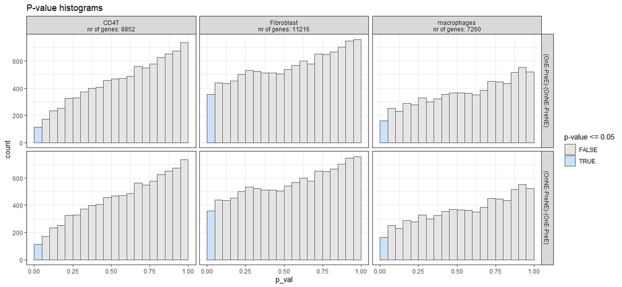

```r
DE_info$hist_pvals
```

The p-value distributions do look suboptimal here (for comparison to appropriate distributions: detailed_analysis_steps_MISC.md). This might point to issues in the DE model definition. For example in case we did not add all important covariates, there is substructure present in the groups, etc.

If there are some issues, you can use the empiricall null procedure from Efron. This is a procedure that will define empirical p-values based on the observed distribution of the test statistic (here: logFC) and not based on the theoretical distribution. This approach has also been used in the Saturn package: https://github.com/statOmics/satuRn. We only recommend this if the p-value distributions point to possible issues, as is here the case.

### Empirical Null procedure

```r
empirical_pval = TRUE
if(empirical_pval == TRUE){
  DE_info_emp = get_empirical_pvals(DE_info$celltype_de$de_output_tidy)
}
```

Table with logFC and p-values for each gene-celltype-contrast:

```r
DE_info_emp$de_output_tidy_emp %>% arrange(p_emp) %>% head()
## # A tibble: 6 x 11
##   gene     cluster_id  logFC logCPM     F     p_val p_adj.loc  p_adj contrast                   p_emp   p_adj_emp
##   <chr>    <chr>       <dbl>  <dbl> <dbl>     <dbl>     <dbl>  <dbl> <chr>                      <dbl>       <dbl>
## 1 IGKV1.5  macrophages -7.64   5.5   25.7 0.0000046    0.0334 0.0334 (OnNE-PreNE)-(OnE-PreE) 8.17e-11 0.000000593
## 2 IGKV1.5  macrophages  7.64   5.5   25.7 0.0000046    0.0334 0.0334 (OnE-PreE)-(OnNE-PreNE) 8.17e-11 0.000000593
## 3 IGHV4.39 CD4T        -5.17   4.17  14.8 0.000287     1      1      (OnNE-PreNE)-(OnE-PreE) 1.52e- 8 0.000134
## 4 IGHV4.39 CD4T         5.17   4.17  14.8 0.000287     1      1      (OnE-PreE)-(OnNE-PreNE) 1.52e- 8 0.000134
## 5 CCL4L2   CD4T         3.65   6.22  12   0.001        1      1      (OnNE-PreNE)-(OnE-PreE) 2.96e- 7 0.00131
## 6 CCL4L2   CD4T        -3.65   6.22  12   0.001        1      1      (OnE-PreE)-(OnNE-PreNE) 2.96e- 7 0.00131
```

The following plot shows the distributions of those corrected, empirical p-values:

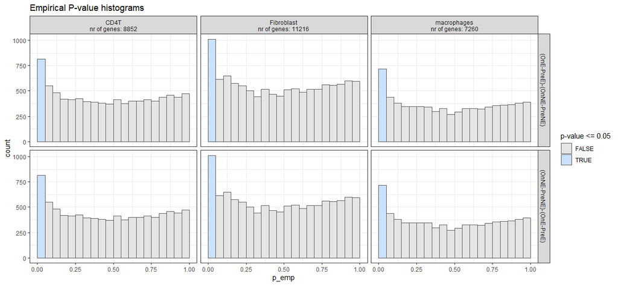

```r
DE_info_emp$hist_pvals_emp
```

These look already better now.

The following plots show how well the correction worked. The green fitted curve should fit well with the histogram. If not, this might point to some issues in the DE model definition.

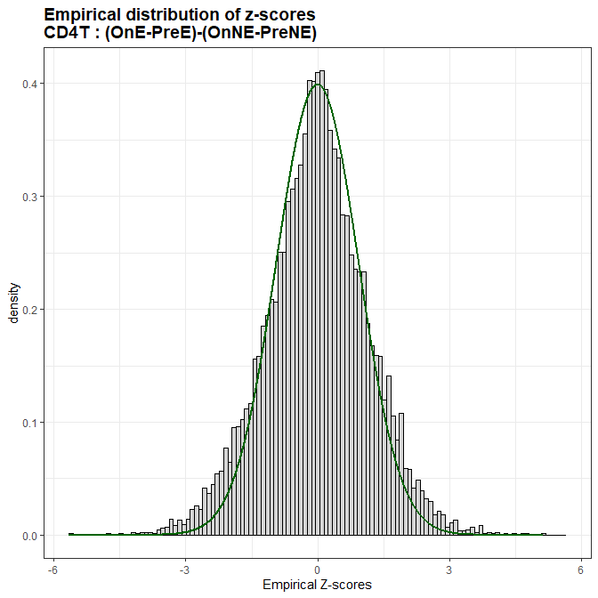

```
##
## $`CD4T.(OnNE-PreNE)-(OnE-PreE)`
```

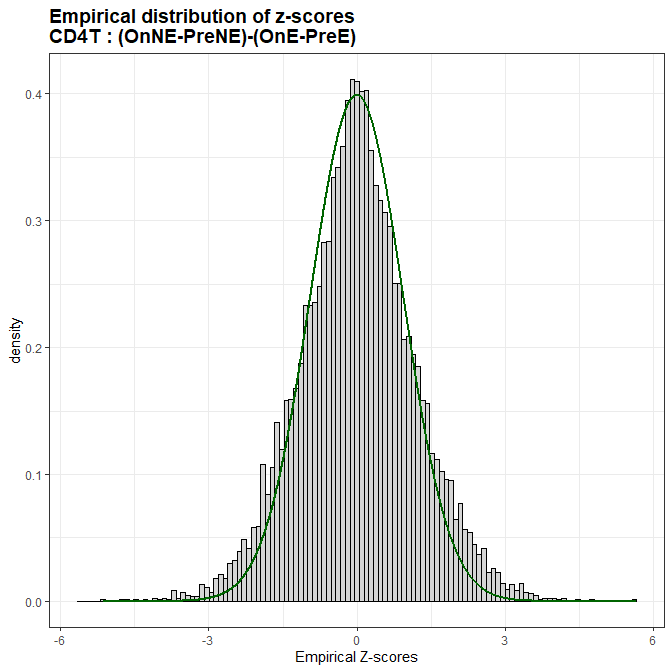

```
##
## $`Fibroblast.(OnE-PreE)-(OnNE-PreNE)`
```

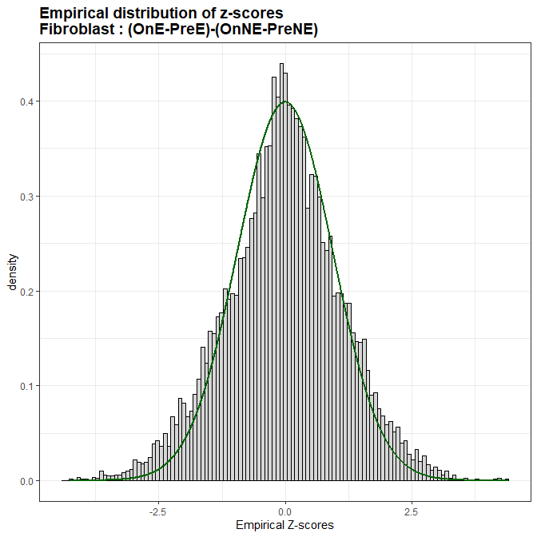

```
##
## $`Fibroblast.(OnNE-PreNE)-(OnE-PreE)`
```

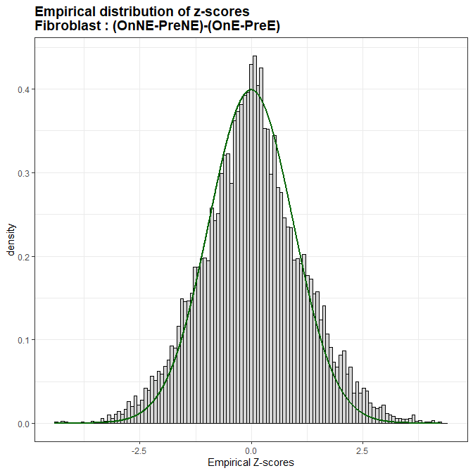

```
##
## $`macrophages.(OnE-PreE)-(OnNE-PreNE)`
```

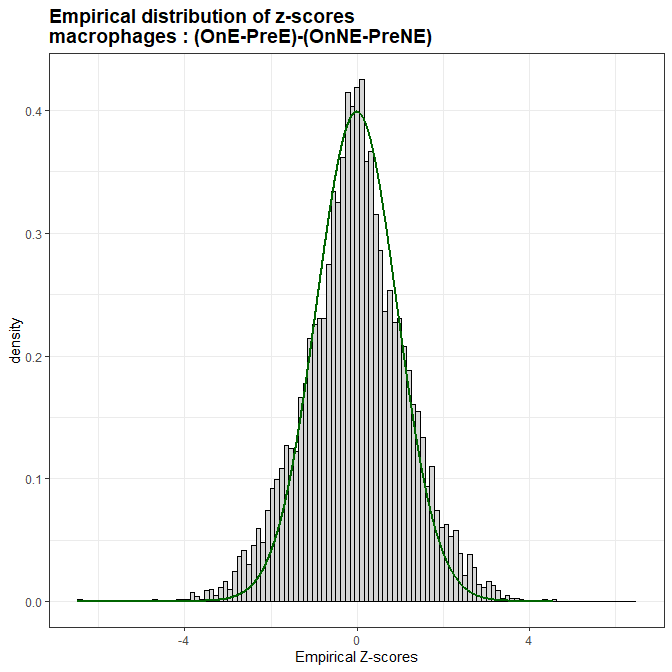

```
##
## $`macrophages.(OnNE-PreNE)-(OnE-PreE)`
```

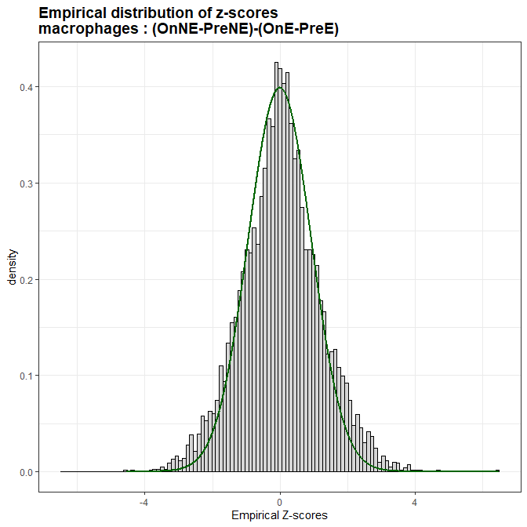

```r
DE_info_emp$z_distr_plots_emp_pval
## $`CD4T.(OnE-PreE)-(OnNE-PreNE)`
```

In general, these plots look OK.

Next, we will compare the empirical p-values to the original ones before. We will look for the concordance between p-values rankings of the original and empirical DE analysis (via ranking-line and upset plots):

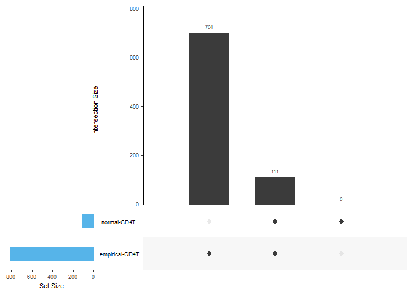

```
##
## [[1]][[2]]
```

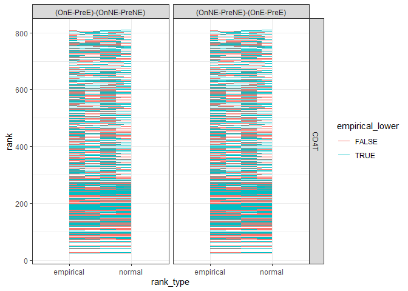

```
##
##
## [[2]]
## [[2]][[1]]
```

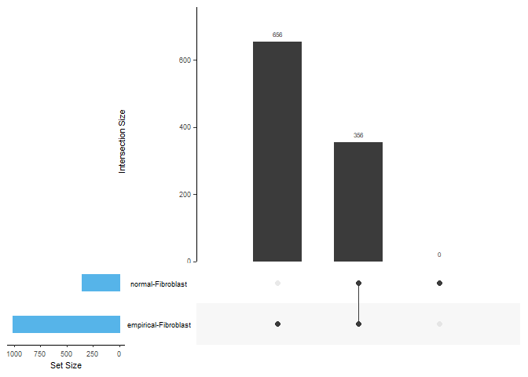

```
##
## [[2]][[2]]
```

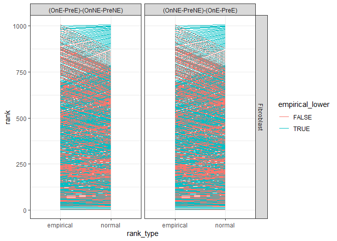

```
##
##
## [[3]]
## [[3]][[1]]
```

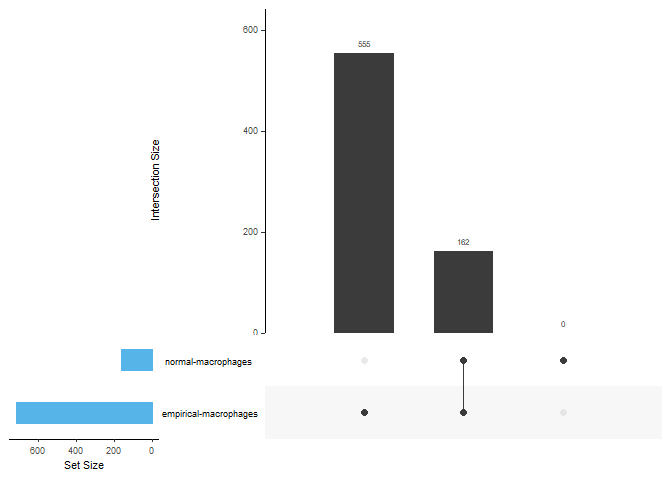

```
##
## [[3]][[2]]
```

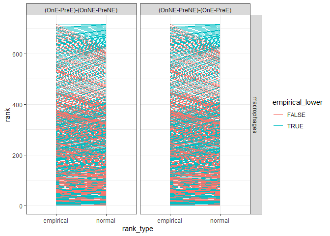

```r
comparison_plots = compare_normal_emp_pvals(DE_info, DE_info_emp, adj_pval = FALSE)
comparison_plots
## [[1]]
## [[1]][[1]]
```

You can see that for some cell types, the genes considered to be DE can change.

### Conclusion of the diagnostic plots concerning the DE analysis

P-value histograms of the normal p-values did not look good here, pointing to possible violations of the model assumptions. Therefore we estimated empirical p-values and we will continue with the MultiNicheNet analysis with these empirical p-values (set `empirical_pval = TRUE` in next code chunk).

```r
empirical_pval = TRUE
if(empirical_pval == FALSE){
  celltype_de = DE_info$celltype_de$de_output_tidy
} else {
  celltype_de = DE_info_emp$de_output_tidy_emp %>% dplyr::select(-p_val, -p_adj) %>% dplyr::rename(p_val = p_emp, p_adj = p_adj_emp)
}
```

In the next step, we will combine the DE information of senders and receivers by linking their ligands and receptors together:

### Combine DE information for ligand-senders and receptors-receivers (similar to step1 - `abundance_expression_info$sender_receiver_info`)

```r
sender_receiver_de = combine_sender_receiver_de(
  sender_de = celltype_de,
  receiver_de = celltype_de,
  senders_oi = senders_oi,
  receivers_oi = receivers_oi,
  lr_network = lr_network
)
```

```r
sender_receiver_de %>% head(20)
## # A tibble: 20 x 12
##    contrast                sender      receiver    ligand  receptor lfc_ligand lfc_receptor ligand_receptor_lfc_avg p_val_ligand p_adj_ligand p_val_receptor p_adj_receptor
##    <chr>                   <chr>       <chr>       <chr>   <chr>         <dbl>        <dbl>                   <dbl>        <dbl>        <dbl>          <dbl>          <dbl>
##  1 (OnNE-PreNE)-(OnE-PreE) macrophages CD4T        CCL17   CCR4           5.62       0.339                     2.98  0.00000526       0.0127         0.128            0.689
##  2 (OnNE-PreNE)-(OnE-PreE) Fibroblast  CD4T        PIP     NPTN           4.4        0.329                     2.36  0.00719          0.334          0.160            0.732
##  3 (OnNE-PreNE)-(OnE-PreE) macrophages Fibroblast  CXCL13  ACKR4          4.04       0.529                     2.28  0.000283         0.0977         0.452            0.947
##  4 (OnNE-PreNE)-(OnE-PreE) Fibroblast  macrophages PIP     NPTN           4.4        0.162                     2.28  0.00719          0.334          0.565            0.980
##  5 (OnNE-PreNE)-(OnE-PreE) Fibroblast  Fibroblast  PIP     NPTN           4.4        0.125                     2.26  0.00719          0.334          0.718            0.999
##  6 (OnNE-PreNE)-(OnE-PreE) macrophages CD4T        CXCL13  CXCR5          4.04       0.461                     2.25  0.000283         0.0977         0.226            0.801
##  7 (OnNE-PreNE)-(OnE-PreE) Fibroblast  Fibroblast  PIP     CD4            4.4        0.0816                    2.24  0.00719          0.334          0.948            0.999
##  8 (OnNE-PreNE)-(OnE-PreE) Fibroblast  CD4T        PIP     CD4            4.4       -0.0236                    2.19  0.00719          0.334          0.841            0.998
##  9 (OnNE-PreNE)-(OnE-PreE) macrophages Fibroblast  CXCL13  CCR10          4.04       0.245                     2.14  0.000283         0.0977         0.531            0.974
## 10 (OnNE-PreNE)-(OnE-PreE) CD4T        CD4T        CCL4L2  CCR1           3.65       0.494                     2.07  0.000000296      0.00131        0.387            0.904
## 11 (OnNE-PreNE)-(OnE-PreE) Fibroblast  macrophages PIP     CD4            4.4       -0.328                     2.04  0.00719          0.334          0.0635           0.544
## 12 (OnE-PreE)-(OnNE-PreNE) CD4T        Fibroblast  CXCL14  CXCR4          2.65       1.28                      1.96  0.000617         0.102          0.0547           0.571
## 13 (OnE-PreE)-(OnNE-PreNE) Fibroblast  Fibroblast  CDH2    CDH2           1.96       1.96                      1.96  0.00263          0.275          0.00263          0.275
## 14 (OnNE-PreNE)-(OnE-PreE) macrophages CD4T        CXCL13  CXCR3          4.04      -0.142                     1.95  0.000283         0.0977         0.484            0.949
## 15 (OnNE-PreNE)-(OnE-PreE) Fibroblast  macrophages SAA1    CD36           2.77       1.06                      1.92  0.00770          0.339          0.0895           0.603
## 16 (OnNE-PreNE)-(OnE-PreE) CD4T        macrophages CCL4L2  CCR5           3.65       0.119                     1.88  0.000000296      0.00131        0.840            0.999
## 17 (OnE-PreE)-(OnNE-PreNE) Fibroblast  Fibroblast  HLA.DRA CD37           1.7        2.02                      1.86  0.000527         0.165          0.00570          0.321
## 18 (OnE-PreE)-(OnNE-PreNE) Fibroblast  Fibroblast  AREG    MMP9           2.67       1.02                      1.84  0.00318          0.275          0.315            0.873
## 19 (OnE-PreE)-(OnNE-PreNE) Fibroblast  Fibroblast  PENK    OGFR           3.05       0.469                     1.76  0.0104           0.359          0.0175           0.419
## 20 (OnE-PreE)-(OnNE-PreNE) Fibroblast  Fibroblast  MMP7    SDC1           3.2        0.312                     1.76  0.00392          0.292          0.539            0.974
```

# Step 3: Predict NicheNet ligand activities and NicheNet ligand-target links based on these differential expression results

## Define the parameters for the NicheNet ligand activity analysis

Here, we need to define the thresholds that will be used to consider genes as differentially expressed or not (logFC, p-value, decision whether to use adjusted or normal p-value, minimum fraction of cells that should express a gene in at least one sample in a group, whether to use the normal p-values or empirical p-values).

NicheNet ligand activity will then be calculated as the enrichment of predicted target genes of ligands in this set of DE genes compared to the genomic background. Here we choose for a minimum logFC of 0.50, maximum p-value of 0.05, and minimum fraction of expression of 0.05.

```r
logFC_threshold = 0.50
p_val_threshold = 0.05
fraction_cutoff = 0.05
```

We will here choose for applying the p-value cutoff on the normal p-values, and not on the p-values corrected for multiple testing. This choice was made here because this dataset has only a few samples per group and we might have a lack of statistical power due to pseudobulking. In case of more samples per group, and a sufficient high number of DE genes per group-celltype (> 20-50), we would recommend using the adjusted p-values.

```r
# p_val_adj = TRUE
p_val_adj = FALSE
```

For the NicheNet ligand-target inference, we also need to select which top n of the predicted target genes will be considered (here: top 250 targets per ligand).

```r
top_n_target = 250
```

The NicheNet ligand activity analysis can be run in parallel for each receiver cell type, by changing the number of cores as defined here. This is only recommended if you have many receiver cell type.

```r
verbose = TRUE
cores_system = 8
n.cores = min(cores_system, sender_receiver_de$receiver %>% unique() %>% length()) # use one core per receiver cell type
```

## Run the NicheNet ligand activity analysis

(this might take some time)

```r
ligand_activities_targets_DEgenes = suppressMessages(suppressWarnings(get_ligand_activities_targets_DEgenes(
  receiver_de = celltype_de,
  receivers_oi = receivers_oi,
  ligand_target_matrix = ligand_target_matrix,
  logFC_threshold = logFC_threshold,
  p_val_threshold = p_val_threshold,
  p_val_adj = p_val_adj,
  top_n_target = top_n_target,
  verbose = verbose,
  n.cores = n.cores
)))
```

Check the DE genes used for the activity analysis

```r
ligand_activities_targets_DEgenes$de_genes_df %>% head(20)
## # A tibble: 20 x 6
##    gene       receiver logFC    p_val p_adj contrast
##    <chr>      <chr>    <dbl>    <dbl> <dbl> <chr>
##  1 AC007388.1 CD4T     0.507 0.0471   0.532 (OnE-PreE)-(OnNE-PreNE)
##  2 AC008124.1 CD4T     0.541 0.00911  0.313 (OnE-PreE)-(OnNE-PreNE)
##  3 AC084033.3 CD4T     0.544 0.0116   0.334 (OnE-PreE)-(OnNE-PreNE)
##  4 AC245014.3 CD4T     0.682 0.0228   0.412 (OnE-PreE)-(OnNE-PreNE)
##  5 ACOT4      CD4T     0.95  0.00502  0.253 (OnE-PreE)-(OnNE-PreNE)
##  6 ACOX3      CD4T     0.58  0.0266   0.436 (OnE-PreE)-(OnNE-PreNE)
##  7 AGPAT5     CD4T     0.628 0.00230  0.182 (OnE-PreE)-(OnNE-PreNE)
##  8 AL133415.1 CD4T     0.691 0.0320   0.467 (OnE-PreE)-(OnNE-PreNE)
##  9 ALG11      CD4T     0.711 0.00696  0.282 (OnE-PreE)-(OnNE-PreNE)
## 10 ANTXR2     CD4T     0.587 0.00123  0.136 (OnE-PreE)-(OnNE-PreNE)
## 11 AP4E1      CD4T     0.7   0.00600  0.268 (OnE-PreE)-(OnNE-PreNE)
## 12 AP4M1      CD4T     0.519 0.0320   0.467 (OnE-PreE)-(OnNE-PreNE)
## 13 APOBR      CD4T     0.889 0.000768 0.113 (OnE-PreE)-(OnNE-PreNE)
## 14 APOC1      CD4T     0.908 0.0198   0.399 (OnE-PreE)-(OnNE-PreNE)
## 15 APOE       CD4T     1.07  0.00255  0.189 (OnE-PreE)-(OnNE-PreNE)
## 16 ARL5B      CD4T     0.754 0.00151  0.156 (OnE-PreE)-(OnNE-PreNE)
## 17 ARSG       CD4T     0.549 0.0180   0.387 (OnE-PreE)-(OnNE-PreNE)
## 18 ATN1       CD4T     0.544 0.0192   0.394 (OnE-PreE)-(OnNE-PreNE)
## 19 AUH        CD4T     0.528 0.00297  0.210 (OnE-PreE)-(OnNE-PreNE)
## 20 BCS1L      CD4T     0.629 0.0245   0.425 (OnE-PreE)-(OnNE-PreNE)
```

Check the output of the activity analysis

```r
ligand_activities_targets_DEgenes$ligand_activities %>% head(20)
## # A tibble: 20 x 8
## # Groups:   receiver, contrast [1]
##    ligand activity contrast                target    ligand_target_weight receiver direction_regulation activity_scaled
##    <chr>     <dbl> <chr>                   <chr>                    <dbl> <chr>    <fct>                          <dbl>
##  1 A2M    -0.00263 (OnE-PreE)-(OnNE-PreNE) CD70                   0.00689 CD4T     up                            -0.412
##  2 A2M    -0.00263 (OnE-PreE)-(OnNE-PreNE) CEBPD                  0.00752 CD4T     up                            -0.412
##  3 A2M    -0.00263 (OnE-PreE)-(OnNE-PreNE) IL2RA                  0.00743 CD4T     up                            -0.412
##  4 A2M    -0.00263 (OnE-PreE)-(OnNE-PreNE) SHC1                   0.00671 CD4T     up                            -0.412
##  5 A2M    -0.00263 (OnE-PreE)-(OnNE-PreNE) SLC1A5                 0.00710 CD4T     up                            -0.412
##  6 A2M    -0.00263 (OnE-PreE)-(OnNE-PreNE) SLC2A1                 0.00739 CD4T     up                            -0.412
##  7 A2M    -0.00263 (OnE-PreE)-(OnNE-PreNE) THBS1                  0.0104  CD4T     up                            -0.412
##  8 AANAT  -0.00248 (OnE-PreE)-(OnNE-PreNE) CEBPD                  0.00408 CD4T     up                            -0.280
##  9 AANAT  -0.00248 (OnE-PreE)-(OnNE-PreNE) IL2RA                  0.00425 CD4T     up                            -0.280
## 10 AANAT  -0.00248 (OnE-PreE)-(OnNE-PreNE) NBPF1                  0.00445 CD4T     up                            -0.280
## 11 AANAT  -0.00248 (OnE-PreE)-(OnNE-PreNE) SHC1                   0.00405 CD4T     up                            -0.280
## 12 AANAT  -0.00248 (OnE-PreE)-(OnNE-PreNE) SLC1A5                 0.00416 CD4T     up                            -0.280
## 13 AANAT  -0.00248 (OnE-PreE)-(OnNE-PreNE) SLC2A1                 0.00481 CD4T     up                            -0.280
## 14 AANAT  -0.00248 (OnE-PreE)-(OnNE-PreNE) THBS1                  0.00599 CD4T     up                            -0.280
## 15 ABCA1  -0.00202 (OnE-PreE)-(OnNE-PreNE) ACOX3                  0.0447  CD4T     up                             0.122
## 16 ABCA1  -0.00202 (OnE-PreE)-(OnNE-PreNE) EIF4ENIF1              0.0436  CD4T     up                             0.122
## 17 ABCA1  -0.00202 (OnE-PreE)-(OnNE-PreNE) HLA.DRA                0.0464  CD4T     up                             0.122
## 18 ABCA1  -0.00202 (OnE-PreE)-(OnNE-PreNE) TSTD2                  0.0432  CD4T     up                             0.122
## 19 ABCA1  -0.00202 (OnE-PreE)-(OnNE-PreNE) VKORC1                 0.0438  CD4T     up                             0.122
## 20 ABCA1  -0.00202 (OnE-PreE)-(OnNE-PreNE) ZNF235                 0.0425  CD4T     up                             0.122
```

# Step 4: Use the information collected above to prioritize all sender-ligand—receiver-receptor pairs.

In the 3 previous steps, we calculated expression, differential expression and NicheNet activity information. Now we will combine these different types of information in one prioritization scheme.

MultiNicheNet allows the user to define the weights of the following criteria to prioritize ligand-receptor interactions:

- Upregulation of the ligand in a sender cell type and/or upregulation of the receptor in a receiver cell type - in the condition of interest. : `de_ligand` and `de_receptor`
- Sufficiently high expression levels of ligand and receptor in many samples of the same group (to mitigate the influence of outlier samples). : `frac_exprs_ligand_receptor`
- Cell-type and condition specific expression of the ligand in the sender cell type and receptor in the receiver cell type (to mitigate the influence of upregulated but still relatively weakly expressed ligands/receptors) : `exprs_ligand` and `exprs_receptor`
- High NicheNet ligand activity, to further prioritize ligand-receptor pairs based on their predicted effect of the ligand-receptor interaction on the gene expression in the receiver cell type : `activity_scaled`
- High relative abundance of sender and/or receiver in the condition of interest: `abund_sender` and `abund_receiver` (experimental feature - not recommended to give non-zero weights for default analyses)

The different properties of the sender-ligand—receiver-receptor pairs can be weighted according to the user’s preference and insight in the dataset at hand.

## Define the prioritization weights, and prepare grouping objects

We will set our preference for this dataset as follows - and recommend the user to use the same weights by default:

```r
prioritizing_weights_DE = c("de_ligand" = 1,
                         "de_receptor" = 1)
prioritizing_weights_activity = c("activity_scaled" = 2)

prioritizing_weights_expression_specificity = c("exprs_ligand" = 2,
                         "exprs_receptor" = 2)

prioritizing_weights_expression_sufficiency = c("frac_exprs_ligand_receptor" = 1)

prioritizing_weights_relative_abundance = c( "abund_sender" = 0,
                         "abund_receiver" = 0)
```

```r
prioritizing_weights = c(prioritizing_weights_DE,
                         prioritizing_weights_activity,
                         prioritizing_weights_expression_specificity,
                         prioritizing_weights_expression_sufficiency,
                         prioritizing_weights_relative_abundance)
```

Make necessary grouping data frame

```r
sender_receiver_tbl = sender_receiver_de %>% dplyr::distinct(sender, receiver)

metadata_combined = SummarizedExperiment::colData(sce) %>% tibble::as_tibble()

if(!is.na(batches)){
  grouping_tbl = metadata_combined[,c(sample_id, group_id, batches)] %>% tibble::as_tibble() %>% dplyr::distinct()
  colnames(grouping_tbl) = c("sample","group",batches)
} else {
  grouping_tbl = metadata_combined[,c(sample_id, group_id)] %>% tibble::as_tibble() %>% dplyr::distinct()
  colnames(grouping_tbl) = c("sample","group")
}
```

Crucial note: grouping_tbl: group should be the same as in the contrast_tbl, and as in the expression info tables! Rename accordingly if this would not be the case. If you followed the guidelines of this tutorial closely, there should be no problem.

## Run the prioritization

```r
prioritization_tables = suppressMessages(generate_prioritization_tables(
  sender_receiver_info = abundance_expression_info$sender_receiver_info,
  sender_receiver_de = sender_receiver_de,
  ligand_activities_targets_DEgenes = ligand_activities_targets_DEgenes,
  contrast_tbl = contrast_tbl,
  sender_receiver_tbl = sender_receiver_tbl,
  grouping_tbl = grouping_tbl,
  prioritizing_weights = prioritizing_weights,
  fraction_cutoff = fraction_cutoff,
  abundance_data_receiver = abundance_expression_info$abundance_data_receiver,
  abundance_data_sender = abundance_expression_info$abundance_data_sender
))
```

Check the output tables

First: group-based summary table

```r
prioritization_tables$group_prioritization_tbl %>% head(20)
## # A tibble: 20 x 60
##    contrast      group sender recei~1 ligand recep~2 lfc_l~3 lfc_r~4 ligan~5 p_val~6 p_adj~7 p_val~8 p_adj~9 activity direc~* activ~* lr_in~* id    avg_l~* avg_r~* ligan~* fract~* fract~* ligan~* rel_a~* rel_a~* sende~*
##    <chr>         <chr> <chr>  <chr>   <chr>  <chr>     <dbl>   <dbl>   <dbl>   <dbl>   <dbl>   <dbl>   <dbl>    <dbl> <fct>     <dbl> <chr>   <chr>   <dbl>   <dbl>   <dbl>   <dbl>   <dbl>   <dbl>   <dbl>   <dbl>   <dbl>
##  1 (OnE-PreE)-(~ OnE   macro~ Fibrob~ TNF    LTBR      0.845  0.181    0.513  0.0658   0.547 0.214     0.794  9.81e-2 up       3.30   TNF_LT~ TNF_~   0.245  0.294   0.0720   0.219  0.379   0.0828   1.00    0.001   0.501
##  2 (OnE-PreE)-(~ OnE   macro~ Fibrob~ TNF    LTBR      0.845  0.181    0.513  0.0658   0.547 0.214     0.794 -3.62e-3 down     0.194  TNF_LT~ TNF_~   0.245  0.294   0.0720   0.219  0.379   0.0828   1.00    0.001   0.501
##  3 (OnE-PreE)-(~ OnE   Fibro~ CD4T    TGM2   ITGA4     1.41   0.311    0.860  0.0182   0.422 0.0401    0.495 -1.90e-3 up       0.221  TGM2_I~ TGM2~   0.199  0.303   0.0604   0.203  0.345   0.0701   0.001   0.898   0.450
##  4 (OnE-PreE)-(~ OnE   Fibro~ CD4T    TGM2   ITGA4     1.41   0.311    0.860  0.0182   0.422 0.0401    0.495  1.03e-2 down     2.48   TGM2_I~ TGM2~   0.199  0.303   0.0604   0.203  0.345   0.0701   0.001   0.898   0.450
##  5 (OnE-PreE)-(~ OnE   macro~ macrop~ TNF    LTBR      0.845  0.184    0.514  0.0658   0.547 0.260     0.825  2.97e-2 up       4.86   TNF_LT~ TNF_~   0.245  0.242   0.0591   0.219  0.327   0.0715   1.00    1.00    1.00
##  6 (OnE-PreE)-(~ OnE   macro~ macrop~ TNF    LTBR      0.845  0.184    0.514  0.0658   0.547 0.260     0.825  1.81e-3 down    -2.14   TNF_LT~ TNF_~   0.245  0.242   0.0591   0.219  0.327   0.0715   1.00    1.00    1.00
##  7 (OnE-PreE)-(~ OnE   macro~ CD4T    TNF    TRAF2     0.845  0.285    0.565  0.0658   0.547 0.149     0.714  7.88e-4 up       2.56   TNF_TR~ TNF_~   0.245  0.0682  0.0167   0.219  0.0950  0.0208   1.00    0.898   0.950
##  8 (OnE-PreE)-(~ OnE   macro~ CD4T    TNF    TRAF2     0.845  0.285    0.565  0.0658   0.547 0.149     0.714  4.34e-3 down    -0.748  TNF_TR~ TNF_~   0.245  0.0682  0.0167   0.219  0.0950  0.0208   1.00    0.898   0.950
##  9 (OnE-PreE)-(~ OnE   macro~ CD4T    CXCL9  CXCR3     1.61   0.142    0.876  0.0745   0.581 0.484     0.949 -2.60e-3 up      -0.383  CXCL9_~ CXCL~   1.49   0.321   0.478    0.596  0.364   0.217    1.00    0.898   0.950
## 10 (OnE-PreE)-(~ OnE   macro~ CD4T    CXCL9  CXCR3     1.61   0.142    0.876  0.0745   0.581 0.484     0.949  1.14e-2 down     3.04   CXCL9_~ CXCL~   1.49   0.321   0.478    0.596  0.364   0.217    1.00    0.898   0.950
## 11 (OnE-PreE)-(~ OnE   macro~ Fibrob~ TNF    TNFRSF~   0.845  0.0877   0.466  0.0658   0.547 0.530     0.974  9.81e-2 up       3.30   TNF_TN~ TNF_~   0.245  0.500   0.122    0.219  0.582   0.127    1.00    0.001   0.501
## 12 (OnE-PreE)-(~ OnE   macro~ Fibrob~ TNF    TNFRSF~   0.845  0.0877   0.466  0.0658   0.547 0.530     0.974 -3.62e-3 down     0.194  TNF_TN~ TNF_~   0.245  0.500   0.122    0.219  0.582   0.127    1.00    0.001   0.501
## 13 (OnE-PreE)-(~ OnE   Fibro~ CD4T    CXCL9  CXCR3     2.01   0.142    1.08   0.0582   0.584 0.484     0.949 -2.60e-3 up      -0.383  CXCL9_~ CXCL~   0.958  0.321   0.308    0.413  0.364   0.150    0.001   0.898   0.450
## 14 (OnE-PreE)-(~ OnE   Fibro~ CD4T    CXCL9  CXCR3     2.01   0.142    1.08   0.0582   0.584 0.484     0.949  1.14e-2 down     3.04   CXCL9_~ CXCL~   0.958  0.321   0.308    0.413  0.364   0.150    0.001   0.898   0.450
## 15 (OnNE-PreNE)~ OnNE  CD4T   CD4T    PTPRC  DPP4      0.146  0.379    0.262  0.297    0.853 0.0597    0.563  5.63e-3 up      -0.0547 PTPRC_~ PTPR~   1.10   0.101   0.111    0.859  0.132   0.113    0.204   0.204   0.204
## 16 (OnNE-PreNE)~ OnNE  CD4T   CD4T    PTPRC  DPP4      0.146  0.379    0.262  0.297    0.853 0.0597    0.563  2.06e-3 down     3.67   PTPRC_~ PTPR~   1.10   0.101   0.111    0.859  0.132   0.113    0.204   0.204   0.204
## 17 (OnE-PreE)-(~ OnE   Fibro~ macrop~ CSF1   CSF3R     0.431  0.695    0.563  0.125    0.712 0.00214   0.187  1.25e-2 up       1.73   CSF1_C~ CSF1~   0.318  0.302   0.0960   0.383  0.390   0.150    0.001   1.00    0.501
## 18 (OnE-PreE)-(~ OnE   Fibro~ macrop~ CSF1   CSF3R     0.431  0.695    0.563  0.125    0.712 0.00214   0.187  7.46e-3 down     0.461  CSF1_C~ CSF1~   0.318  0.302   0.0960   0.383  0.390   0.150    0.001   1.00    0.501
## 19 (OnE-PreE)-(~ OnE   macro~ CD4T    TNF    TNFRSF~   0.845  0.148    0.496  0.0658   0.547 0.323     0.864  7.88e-4 up       2.56   TNF_TN~ TNF_~   0.245  0.359   0.0879   0.219  0.394   0.0862   1.00    0.898   0.950
## 20 (OnE-PreE)-(~ OnE   macro~ CD4T    TNF    TNFRSF~   0.845  0.148    0.496  0.0658   0.547 0.323     0.864  4.34e-3 down    -0.748  TNF_TN~ TNF_~   0.245  0.359   0.0879   0.219  0.394   0.0862   1.00    0.898   0.950
## # ... with 33 more variables: lfc_pval_ligand <dbl>, p_val_ligand_adapted <dbl>, scaled_lfc_ligand <dbl>, scaled_p_val_ligand <dbl>, scaled_lfc_pval_ligand <dbl>, scaled_p_val_ligand_adapted <dbl>,
## #   lfc_pval_receptor <dbl>, p_val_receptor_adapted <dbl>, scaled_lfc_receptor <dbl>, scaled_p_val_receptor <dbl>, scaled_lfc_pval_receptor <dbl>, scaled_p_val_receptor_adapted <dbl>, activity_up <dbl>,
## #   activity_scaled_up <dbl>, scaled_activity_scaled_up <dbl>, scaled_activity_up <dbl>, activity_down <dbl>, activity_scaled_down <dbl>, scaled_activity_scaled_down <dbl>, scaled_activity_down <dbl>,
## #   scaled_avg_exprs_ligand <dbl>, scaled_avg_frq_ligand <dbl>, pb_ligand_group <dbl>, scaled_pb_ligand <dbl>, scaled_avg_exprs_receptor <dbl>, scaled_avg_frq_receptor <dbl>, pb_receptor_group <dbl>,
## #   scaled_pb_receptor <dbl>, fraction_expressing_ligand_receptor <dbl>, max_scaled_activity <dbl>, na.rm <lgl>, prioritization_score <dbl>, top_group <chr>, and abbreviated variable names 1: receiver, 2: receptor,
## #   3: lfc_ligand, 4: lfc_receptor, 5: ligand_receptor_lfc_avg, 6: p_val_ligand, 7: p_adj_ligand, 8: p_val_receptor, 9: p_adj_receptor, *: direction_regulation, *: activity_scaled, *: lr_interaction,
## #   *: avg_ligand_group, *: avg_receptor_group, *: ligand_receptor_prod_group, *: fraction_ligand_group, *: fraction_receptor_group, *: ligand_receptor_fraction_prod_group, *: rel_abundance_scaled_sender, ...
```

Second: sample-based summary table: contains expression information of each LR pair per sample

```r
prioritization_tables$sample_prioritization_tbl %>% head(20)
## # A tibble: 20 x 26
##    sample       sender      receiver    ligand  recep~1 avg_l~2 avg_r~3 ligan~4 fract~5 fract~6 ligan~7 pb_li~8 pb_re~9 ligan~* group prior~* lr_in~* id    scale~* scale~* scale~* n_cel~* keep_~* n_cel~* keep_~* keep_~*
##    <chr>        <chr>       <chr>       <chr>   <chr>     <dbl>   <dbl>   <dbl>   <dbl>   <dbl>   <dbl>   <dbl>   <dbl>   <dbl> <chr>   <dbl> <chr>   <chr>   <dbl>   <dbl>   <dbl>   <dbl>   <dbl>   <dbl>   <dbl> <fct>
##  1 BIOKEY_24Pre macrophages macrophages HLA.DMA CD74       1.97    4.96    9.79   0.976   1       0.976   10.6     15.1    161. PreNE  NA     HLA.DM~ HLA.~   1.91    1.06    1.10       82       1      82       1 Sender~
##  2 BIOKEY_7On   Fibroblast  macrophages MIF     CD74       2.26    4.29    9.68   0.992   1       0.992   11.5     14.5    167. OnNE    0.479 MIF_CD~ MIF_~   3.32    1.38    2.48      158       1    1176       1 Sender~
##  3 BIOKEY_27Pre macrophages macrophages HLA.DMA CD74       1.96    4.78    9.39   0.957   1       0.957   10.8     15.0    161. PreNE  NA     HLA.DM~ HLA.~   1.70    0.889   1.13       23       1      23       1 Sender~
##  4 BIOKEY_6Pre  macrophages macrophages HLA.DMA CD74       1.87    5.00    9.33   0.966   1       0.966   10.7     15.4    165. PreNE  NA     HLA.DM~ HLA.~   1.68    0.972   1.35      116       1     116       1 Sender~
##  5 BIOKEY_28On  Fibroblast  macrophages MIF     CD74       2.58    3.56    9.18   1       0.997   0.997   11.9     14.3    170. OnE     0.869 MIF_CD~ MIF_~   2.90    1.48    2.75      793       1      37       1 Sender~
##  6 BIOKEY_14Pre macrophages macrophages HLA.DMA CD74       1.82    4.87    8.87   0.938   1       0.938   10.7     15.2    162. PreNE  NA     HLA.DM~ HLA.~   1.44    0.716   1.17       32       1      32       1 Sender~
##  7 BIOKEY_7Pre  Fibroblast  macrophages MIF     CD74       2.10    4.22    8.86   0.991   1       0.991   11.4     14.1    162. PreNE  NA     MIF_CD~ MIF_~   2.64    1.35    1.92       17       1     108       1 Sender~
##  8 BIOKEY_30On  macrophages macrophages HLA.DMA CD74       1.80    4.90    8.85   0.961   1       0.961   10.5     15.2    159. OnNE    0.554 HLA.DM~ HLA.~   1.43    0.931   0.967      77       1      77       1 Sender~
##  9 BIOKEY_30Pre macrophages macrophages HLA.DMA CD74       1.72    4.90    8.41   0.970   1       0.970   10.0     14.8    148. PreNE  NA     HLA.DM~ HLA.~   1.21    1.01    0.250      67       1      67       1 Sender~
## 10 BIOKEY_18Pre macrophages macrophages HLA.DMA CD74       1.71    4.90    8.39   1       1       1       10.3     15.1    156. PreE   NA     HLA.DM~ HLA.~   1.20    1.29    0.744      29       1      29       1 Sender~
## 11 BIOKEY_20Pre macrophages macrophages HLA.DMA CD74       1.68    4.93    8.31   1       1       1        9.66    14.4    139. PreNE  NA     HLA.DM~ HLA.~   1.15    1.29   -0.359       4       0       4       0 Sender~
## 12 BIOKEY_18On  macrophages macrophages HLA.DMA CD74       1.67    4.90    8.16   0.911   1       0.911   10.5     15.4    162. OnE     0.854 HLA.DM~ HLA.~   1.08    0.471   1.18       56       1      56       1 Sender~
## 13 BIOKEY_31Pre macrophages macrophages MIF     CD74       2.41    3.38    8.16   0.977   0.977   0.954   12.0     13.8    166. PreE   NA     MIF_CD~ MIF_~   2.26    1.10    1.75      258       1     258       1 Sender~
## 14 BIOKEY_5On   Fibroblast  macrophages MIF     CD74       1.86    4.37    8.11   1       1       1       10.9     14.3    156. OnE     0.869 MIF_CD~ MIF_~   2.01    1.54    1.26       13       1      63       1 Sender~
## 15 BIOKEY_10On  macrophages macrophages HLA.DMA CD74       1.68    4.74    7.99   0.942   1       0.942   11.0     15.6    172. OnE     0.854 HLA.DM~ HLA.~   0.991   0.754   1.81      326       1     326       1 Sender~
## 16 BIOKEY_12On  macrophages macrophages HLA.DMA CD74       1.65    4.81    7.95   0.976   1       0.976   10.5     15.3    160. OnE     0.854 HLA.DM~ HLA.~   0.973   1.07    1.02      125       1     125       1 Sender~
## 17 BIOKEY_4Pre  macrophages macrophages HLA.DMA CD74       1.68    4.66    7.85   0.938   1       0.938   10.7     15.2    162. PreNE  NA     HLA.DM~ HLA.~   0.919   0.725   1.13       65       1      65       1 Sender~
## 18 BIOKEY_19Pre macrophages macrophages HLA.DMA CD74       1.63    4.81    7.83   0.925   1       0.925   10.3     15.0    155. PreNE  NA     HLA.DM~ HLA.~   0.910   0.602   0.718      40       1      40       1 Sender~
## 19 BIOKEY_28On  macrophages macrophages MIF     CD74       2.17    3.56    7.73   0.987   0.997   0.985   12.2     14.3    173. OnE     0.691 MIF_CD~ MIF_~   1.97    1.34    2.19      793       1     793       1 Sender~
## 20 BIOKEY_27On  macrophages macrophages HLA.DMA CD74       1.77    4.34    7.69   0.958   1       0.958   10.8     14.9    160. OnNE    0.554 HLA.DM~ HLA.~   0.836   0.906   1.03       48       1      48       1 Sender~
## # ... with abbreviated variable names 1: receptor, 2: avg_ligand, 3: avg_receptor, 4: ligand_receptor_prod, 5: fraction_ligand, 6: fraction_receptor, 7: ligand_receptor_fraction_prod, 8: pb_ligand, 9: pb_receptor,
## #   *: ligand_receptor_pb_prod, *: prioritization_score, *: lr_interaction, *: scaled_LR_prod, *: scaled_LR_frac, *: scaled_LR_pb_prod, *: n_cells_receiver, *: keep_receiver, *: n_cells_sender, *: keep_sender,
## #   *: keep_sender_receiver
```

# Step 5: Add information on prior knowledge and expression correlation between LR and target expression.

In multi-sample datasets, we have the opportunity to look whether expression of ligand-receptor across all samples is correlated with the expression of their by NicheNet predicted target genes. This is what we will do with the following line of code:

```r
lr_target_prior_cor = lr_target_prior_cor_inference(prioritization_tables$group_prioritization_tbl$receiver %>% unique(), abundance_expression_info, celltype_de, grouping_tbl, prioritization_tables, ligand_target_matrix, logFC_threshold = logFC_threshold, p_val_threshold = p_val_threshold, p_val_adj = p_val_adj)
```

# Save all the output of MultiNicheNet

To avoid needing to redo the analysis later. All the output written down here is sufficient to make all in-built downstream visualizations.

```r
path = "./"

multinichenet_output = list(
    celltype_info = abundance_expression_info$celltype_info,
    celltype_de = celltype_de,
    sender_receiver_info = abundance_expression_info$sender_receiver_info,
    sender_receiver_de =  sender_receiver_de,
    ligand_activities_targets_DEgenes = ligand_activities_targets_DEgenes,
    prioritization_tables = prioritization_tables,
    grouping_tbl = grouping_tbl,
    lr_target_prior_cor = lr_target_prior_cor
  )
multinichenet_output = make_lite_output(multinichenet_output)

save = FALSE
if(save == TRUE){
  saveRDS(multinichenet_output, paste0(path, "multinichenet_output.rds"))

}
```

# Visualization of the results of the cell-cell communication analysis

In a first instance, we will look at the broad overview of prioritized interactions via condition-specific Circos plots.

## Circos plot of top-prioritized links

We will look here at the top 50 predictions across all contrasts, senders, and receivers of interest.

```r
prioritized_tbl_oi_all = get_top_n_lr_pairs(multinichenet_output$prioritization_tables, 50, rank_per_group = FALSE)
```

```r
prioritized_tbl_oi = multinichenet_output$prioritization_tables$group_prioritization_tbl %>%
  filter(id %in% prioritized_tbl_oi_all$id) %>%
  distinct(id, sender, receiver, ligand, receptor, group) %>% left_join(prioritized_tbl_oi_all)
prioritized_tbl_oi$prioritization_score[is.na(prioritized_tbl_oi$prioritization_score)] = 0

senders_receivers = union(prioritized_tbl_oi$sender %>% unique(), prioritized_tbl_oi$receiver %>% unique()) %>% sort()

colors_sender = RColorBrewer::brewer.pal(n = length(senders_receivers), name = 'Spectral') %>% magrittr::set_names(senders_receivers)
colors_receiver = RColorBrewer::brewer.pal(n = length(senders_receivers), name = 'Spectral') %>% magrittr::set_names(senders_receivers)

circos_list = make_circos_group_comparison(prioritized_tbl_oi, colors_sender, colors_receiver)
```

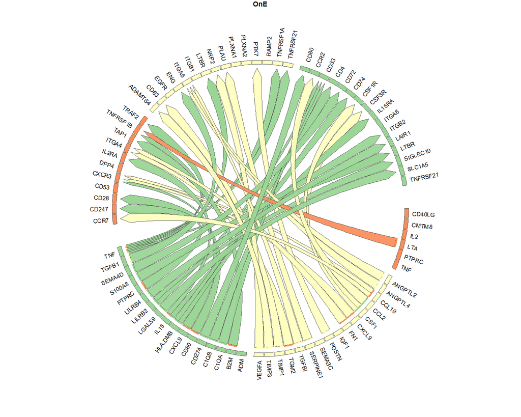

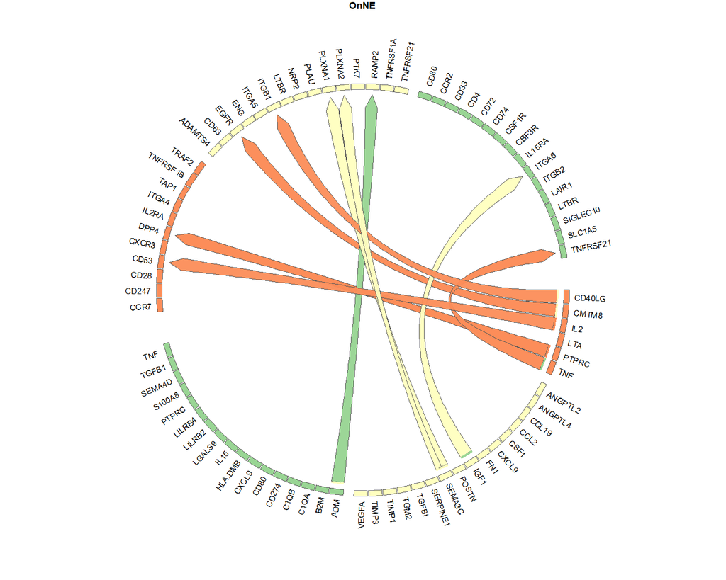

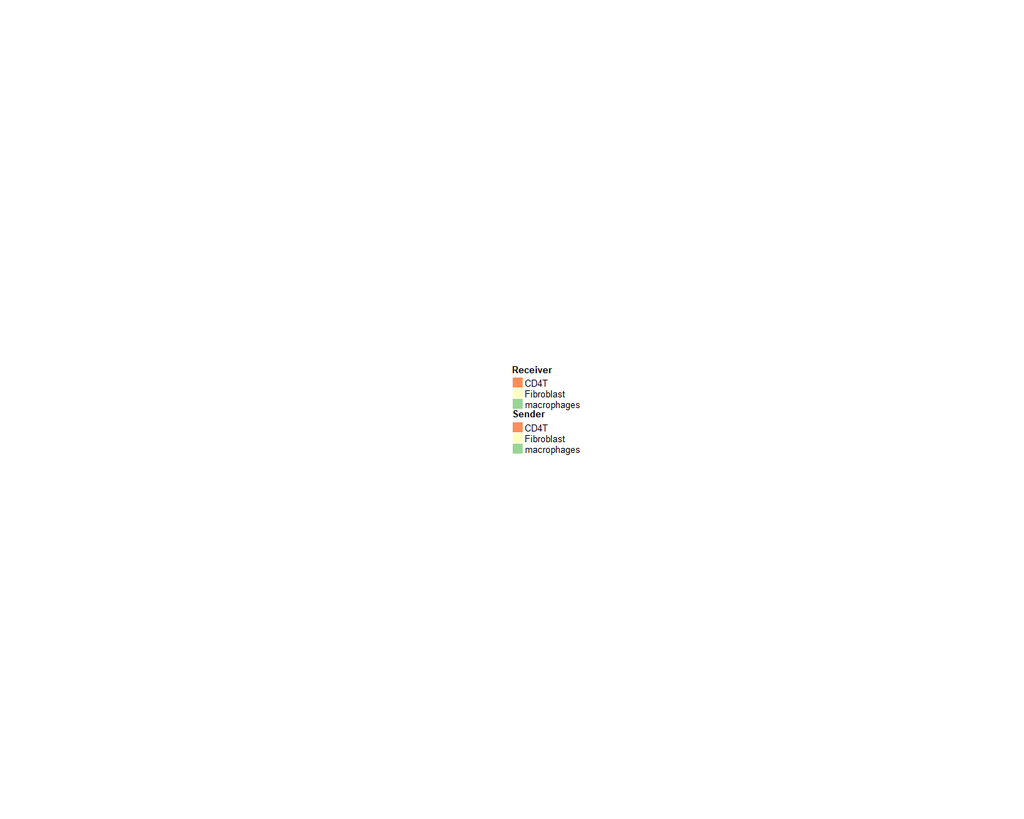

Now you can also make a full circos plot for one group of interest, where will show the top30 per group

```r
prioritized_tbl_oi_E_30 = get_top_n_lr_pairs(multinichenet_output$prioritization_tables, 30, groups_oi = "OnE")
prioritized_tbl_oi_NE_30 = get_top_n_lr_pairs(multinichenet_output$prioritization_tables, 30, groups_oi = "OnNE")
```

```r
circos_E = make_circos_one_group(prioritized_tbl_oi_E_30, colors_sender, colors_receiver)
```

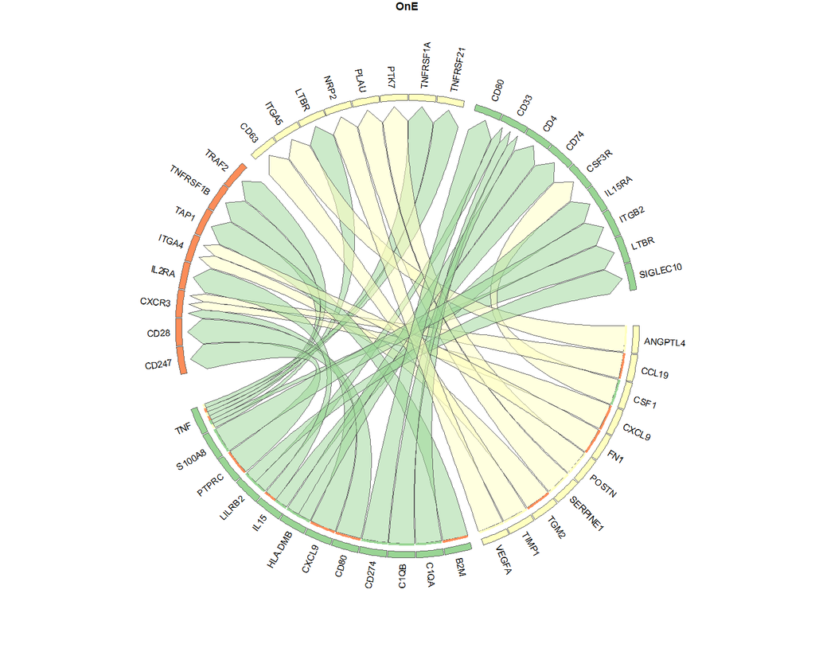

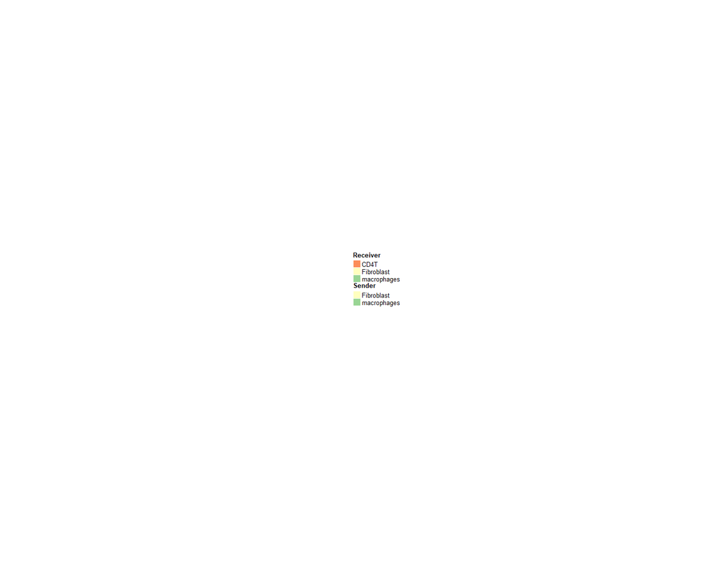

```r
circos_NE = make_circos_one_group(prioritized_tbl_oi_NE_30, colors_sender, colors_receiver)
```

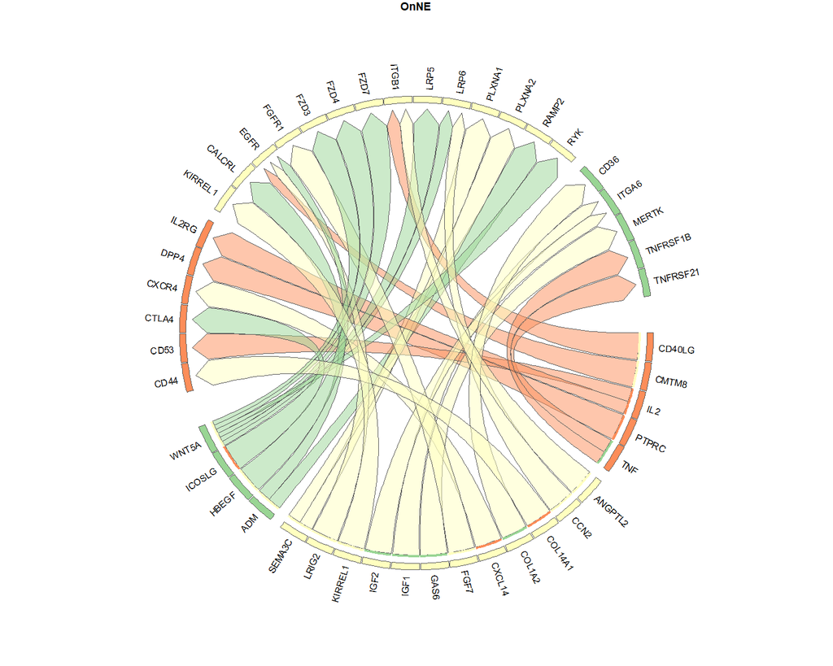

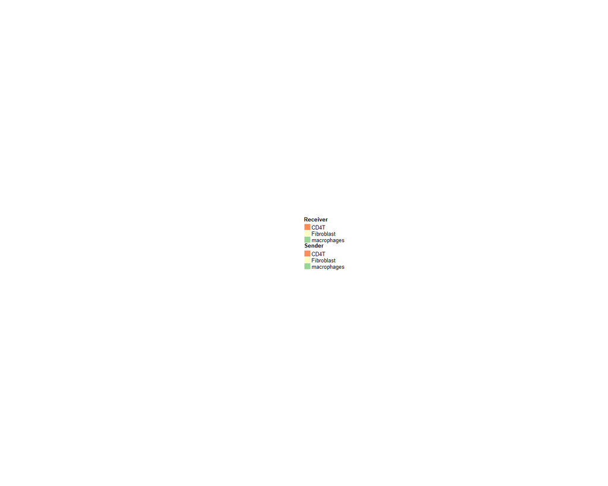

## Visualization of scaled ligand-receptor pseudobulk products and ligand activity

Now we will visualize per sample the scaled product of ligand and receptor expression. Samples that were left out of the DE analysis are indicated with a smaller dot (this helps to indicate the samples that did not contribute to the calculation of the logFC, and thus not contributed to the final prioritization)

We will now check the top 30 interactions that we also visualized in the circos plots above.

E group

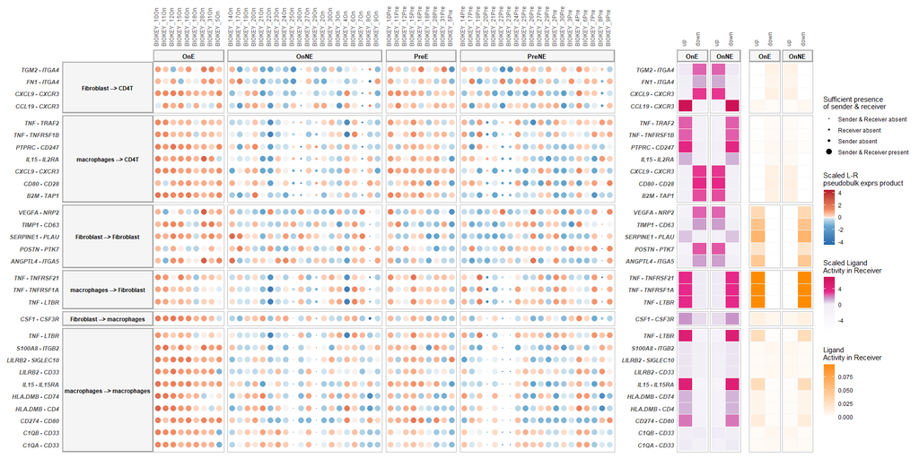

```r
plot_oi = make_sample_lr_prod_activity_plots(multinichenet_output$prioritization_tables, prioritized_tbl_oi_E_30)
plot_oi
```

How should we interpret this plot: this plots shows the top 30 interactions of which the On-vs-Pre change is more strong in the E group than the NE group.

Now for the NE group (top 30 interactions of which the On-vs-Pre change is more strong in the NE group than the E group.)

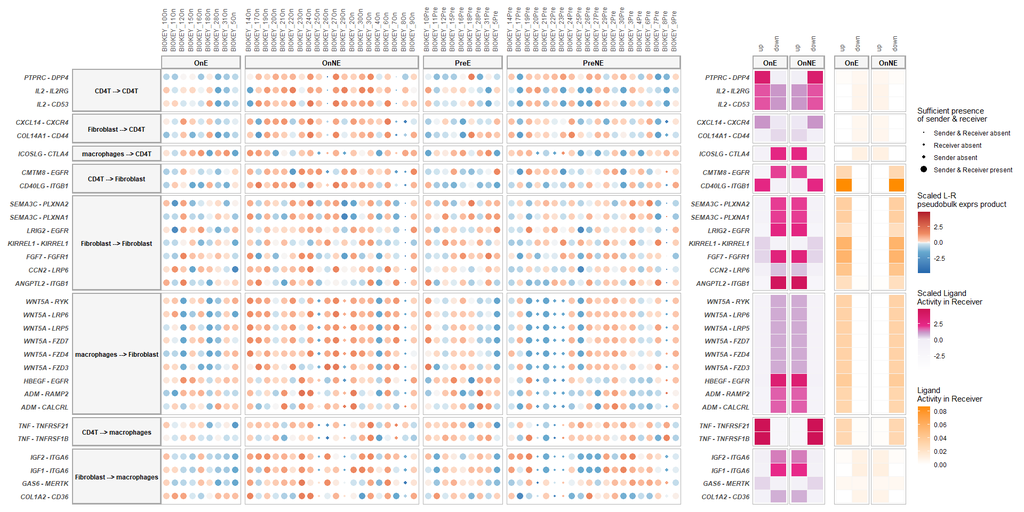

```r
plot_oi = make_sample_lr_prod_activity_plots(multinichenet_output$prioritization_tables, prioritized_tbl_oi_NE_30)
plot_oi
```

Typically, there are way more than 30 differentially expressed and active ligand-receptor pairs per group across all sender-receiver combinations. Therefore it might be useful to zoom in on specific cell types as senders/receivers:

Eg macrophages as receiver:

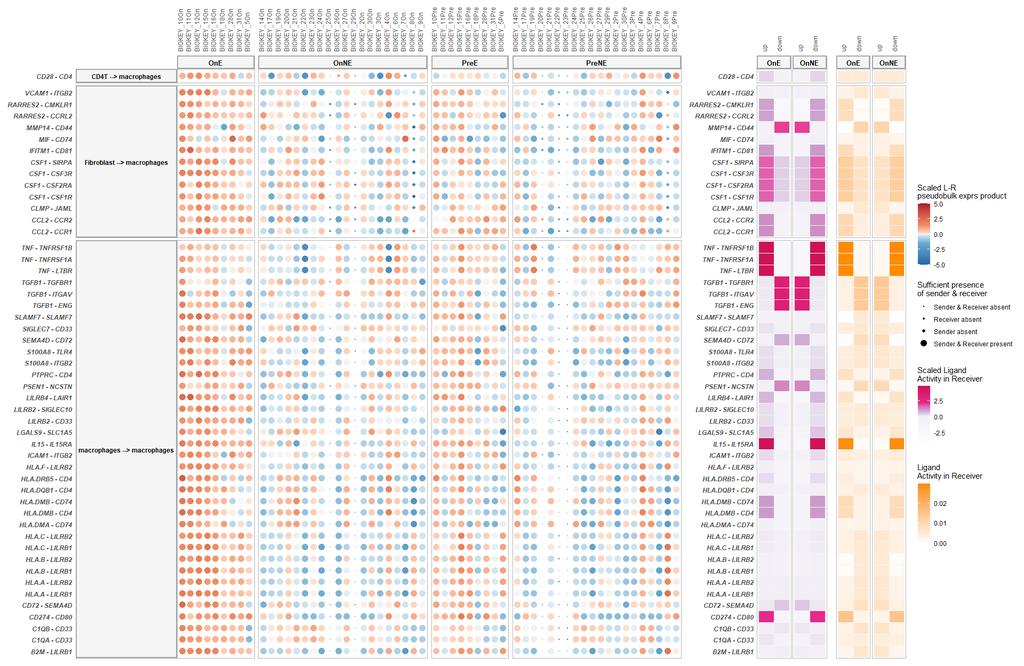

```r
group_oi = "OnE"
prioritized_tbl_oi_top_50 = get_top_n_lr_pairs(multinichenet_output$prioritization_tables, 50, groups_oi = group_oi, receivers_oi = "macrophages")

plot_oi = make_sample_lr_prod_activity_plots(multinichenet_output$prioritization_tables, prioritized_tbl_oi_top_50)
plot_oi
```

Eg macrophages as sender:

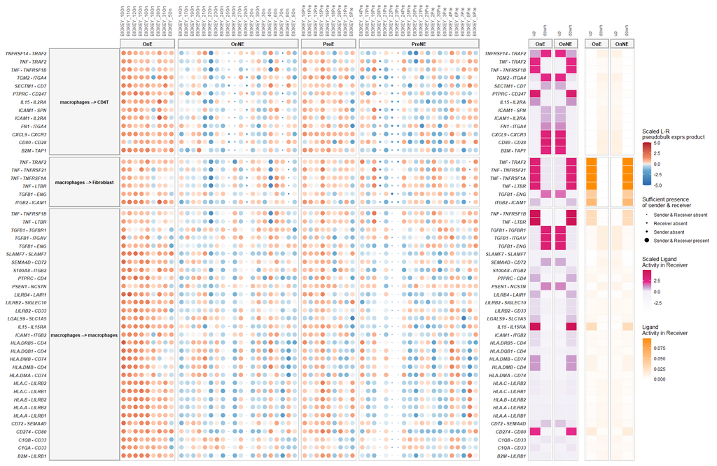

```r
prioritized_tbl_oi_top_50 = get_top_n_lr_pairs(multinichenet_output$prioritization_tables, 50, groups_oi = group_oi, senders_oi = "macrophages")

plot_oi = make_sample_lr_prod_activity_plots(multinichenet_output$prioritization_tables, prioritized_tbl_oi_top_50)
plot_oi
```

## Intercellular regulatory network systems view

As additional plot, we can generate a ‘systems’ view of these intercellular feedback and cascade processes than can be occuring between the different cell populations involved. In this plot, we will draw links between ligands of sender cell types their ligand/receptor-annotated target genes in receiver cell types. So links are ligand-target links (= gene regulatory links) and not ligand-receptor protein-protein interactions!

```r
prioritized_tbl_oi = get_top_n_lr_pairs(multinichenet_output$prioritization_tables, 500, rank_per_group = FALSE)

lr_target_prior_cor_filtered = multinichenet_output$prioritization_tables$group_prioritization_tbl$group %>% unique() %>% lapply(function(group_oi){
  lr_target_prior_cor_filtered = multinichenet_output$lr_target_prior_cor %>% inner_join(multinichenet_output$ligand_activities_targets_DEgenes$ligand_activities %>% distinct(ligand, target, direction_regulation, contrast)) %>% inner_join(contrast_tbl) %>% filter(group == group_oi)
  lr_target_prior_cor_filtered_up = lr_target_prior_cor_filtered %>% filter(direction_regulation == "up") %>% filter( (rank_of_target < top_n_target) & (pearson > 0.50 | spearman > 0.50))
  lr_target_prior_cor_filtered_down = lr_target_prior_cor_filtered %>% filter(direction_regulation == "down") %>% filter( (rank_of_target < top_n_target) & (pearson < -0.50 | spearman < -0.50))
  lr_target_prior_cor_filtered = bind_rows(lr_target_prior_cor_filtered_up, lr_target_prior_cor_filtered_down)
}) %>% bind_rows()
```

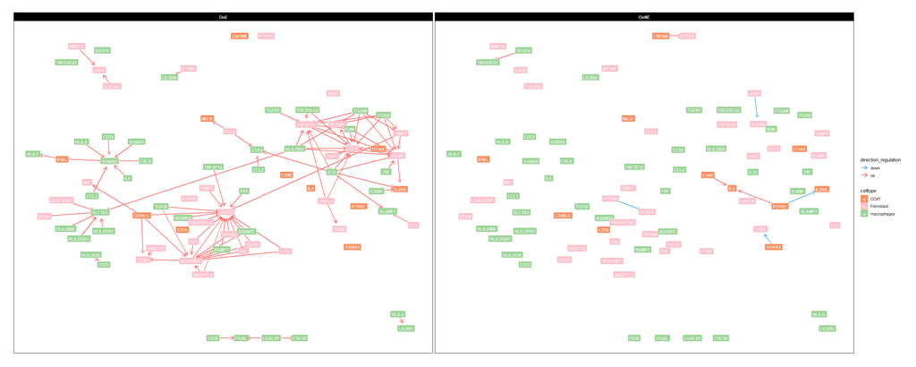

```r
colors_sender["Fibroblast"] = "pink" # the  original yellow with white font is not very readable
graph_plot = make_ggraph_ligand_target_links(lr_target_prior_cor_filtered = lr_target_prior_cor_filtered, prioritized_tbl_oi = prioritized_tbl_oi, colors = colors_sender)
graph_plot$plot
```

```r
graph_plot$source_df_lt %>% head()
## # A tibble: 6 x 6
##   sender            receiver           direction_regulation group type          weight
##   <chr>             <chr>              <fct>                <chr> <chr>          <dbl>
## 1 Fibroblast_TIMP1  Fibroblast_TIMP1   up                   OnE   Ligand-Target      1
## 2 Fibroblast_TIMP1  Fibroblast_VEGFA   up                   OnE   Ligand-Target      1
## 3 Fibroblast_TIMP3  Fibroblast_VEGFA   up                   OnE   Ligand-Target      1
## 4 macrophages_B2M   Fibroblast_CCL5    up                   OnE   Ligand-Target      1
## 5 macrophages_B2M   Fibroblast_TNFSF10 up                   OnE   Ligand-Target      1
## 6 macrophages_ITGB2 Fibroblast_TIMP1   up                   OnE   Ligand-Target      1
graph_plot$nodes_df %>% head()
##                                node    celltype  gene       type_gene
## macrophages_ITGB2 macrophages_ITGB2 macrophages ITGB2 ligand/receptor
## Fibroblast_ICAM1   Fibroblast_ICAM1  Fibroblast ICAM1 ligand/receptor
## Fibroblast_MMP14   Fibroblast_MMP14  Fibroblast MMP14 ligand/receptor
## Fibroblast_JAM3     Fibroblast_JAM3  Fibroblast  JAM3 ligand/receptor
## Fibroblast_VCAM1   Fibroblast_VCAM1  Fibroblast VCAM1 ligand/receptor
## Fibroblast_TIMP1   Fibroblast_TIMP1  Fibroblast TIMP1          ligand
```

## Show ligand activities for each receiver-group combination

In the next type of plot, we plot all the ligand activities (Both scaled and absolute activities) of each receiver-group combination. This can give us some insights in active signaling pathways across groups. Note that we can thus show top ligands based on ligand activity - agnostic of expression in sender.

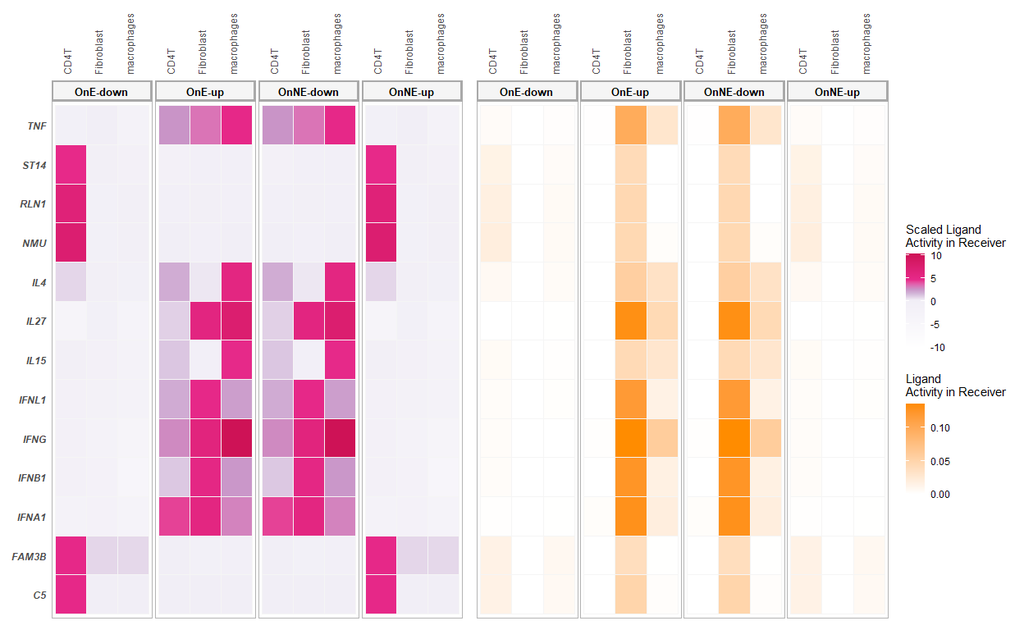

```r
ligands_oi = multinichenet_output$prioritization_tables$ligand_activities_target_de_tbl %>% inner_join(contrast_tbl) %>%
  group_by(group, receiver) %>% distinct(ligand, receiver, group, activity) %>%
  top_n(5, activity) %>% pull(ligand) %>% unique()

plot_oi = make_ligand_activity_plots(multinichenet_output$prioritization_tables, ligands_oi, contrast_tbl, widths = NULL)
plot_oi
```

This plot eg shows a strong interferon signature in all 3 cell types for genes with stronger On-vs-Pre differences in the E than NE group.

## Zoom in on specific ligand-receptor interactions: show their expression in the single-cell data!

Single-cell-based Feature, and Violin plots of ligand-receptor interaction of interest: `make_ligand_receptor_feature_plot` and `make_ligand_receptor_violin_plot`

It is often useful to zoom in on specific ligand-receptor interactions of interest by looking in more detail to their expression at the single cell level

Check the highest scoring links based on the general prioritization score. Here we will pick one of those to visualize.

```r
prioritized_tbl_oi %>% head(10)
## # A tibble: 10 x 8
##    group sender      receiver    ligand receptor id                                  prioritization_score prioritization_rank
##    <chr> <chr>       <chr>       <chr>  <chr>    <chr>                                              <dbl>               <dbl>
##  1 OnE   macrophages Fibroblast  TNF    LTBR     TNF_LTBR_macrophages_Fibroblast                    0.944                   1
##  2 OnE   Fibroblast  CD4T        TGM2   ITGA4    TGM2_ITGA4_Fibroblast_CD4T                         0.940                   2
##  3 OnE   macrophages macrophages TNF    LTBR     TNF_LTBR_macrophages_macrophages                   0.939                   3
##  4 OnE   macrophages CD4T        TNF    TRAF2    TNF_TRAF2_macrophages_CD4T                         0.937                   4
##  5 OnE   macrophages CD4T        CXCL9  CXCR3    CXCL9_CXCR3_macrophages_CD4T                       0.933                   5
##  6 OnE   macrophages Fibroblast  TNF    TNFRSF1A TNF_TNFRSF1A_macrophages_Fibroblast                0.923                   6
##  7 OnE   Fibroblast  CD4T        CXCL9  CXCR3    CXCL9_CXCR3_Fibroblast_CD4T                        0.921                   7
##  8 OnNE  CD4T        CD4T        PTPRC  DPP4     PTPRC_DPP4_CD4T_CD4T                               0.921                   8
##  9 OnE   Fibroblast  macrophages CSF1   CSF3R    CSF1_CSF3R_Fibroblast_macrophages                  0.920                   9
## 10 OnE   macrophages CD4T        TNF    TNFRSF1B TNF_TNFRSF1B_macrophages_CD4T                      0.920                  10
```

```r
ligand_oi = "CXCL9"
receptor_oi = "CXCR3"
group_oi = "OnE"
sender_oi = "macrophages"
receiver_oi = "CD4T"
```

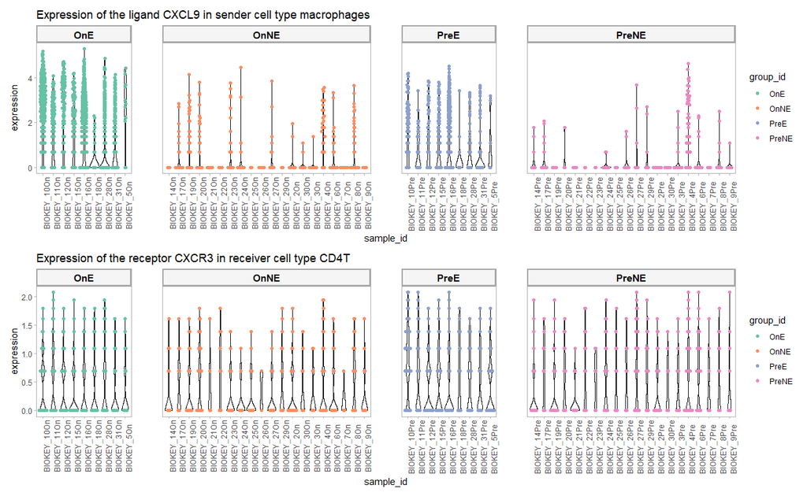

```r
p_violin = make_ligand_receptor_violin_plot(sce_sender = sce, sce_receiver = sce, ligand_oi = ligand_oi, receptor_oi = receptor_oi, group_oi = group_oi, group_id = group_id, sender_oi = sender_oi, receiver_oi = receiver_oi, sample_id = sample_id, celltype_id_sender = celltype_id, celltype_id_receiver = celltype_id)
p_violin
```

For `make_ligand_receptor_feature_plot`, your SingleCellExperiment object should have a dimensionality reduction element stored.

## Plots of cell-cell communication changes

All the above visualizations were general and not specific to the multifactorial design and complex contrast of this data and analysis. In the final part of this vignette, we will demonstrate some visualizations that better showcase differences in therapy-induced cell-cell communication changes. Because it is very hard to do this for the final MultiNicheNet prioritization score including both expression and activity, we will only visualize ligand-receptor expression in the following plots. But realise that the interactions we will show are prioritized by MultiNicheNet not only based on expression, but thus also ligand activity.

Also note that following visualizations should be tailored to the specific multifactorial design of the data you are analyzing.

### Prepare difference plots

In the following blocks of code, we will first create and reformat a data frame so that we know for each sample from which patient it came, whether it was On or Pre therapy, whether the patient is from the E or NE group, and also what the pseudobulk expression product is for a ligand-receptor pair.

As example, we will focus on the top 10 interactions with stronger On-Pre differences in the E group versus the NE group.

```r
# get prioritized interactions
prioritized_tbl_oi = get_top_n_lr_pairs(multinichenet_output$prioritization_tables, 10, rank_per_group = TRUE, groups_oi = "OnE")

# create sample-level data frame for these interactions
sample_data = multinichenet_output$prioritization_tables$sample_prioritization_tbl %>% dplyr::filter(id %in% prioritized_tbl_oi$id) %>% dplyr::mutate(sender_receiver = paste(sender, receiver, sep = " --> "), lr_interaction = paste(ligand, receptor, sep = " - "))   %>%  dplyr::arrange(receiver) %>% dplyr::group_by(receiver) %>%  dplyr::arrange(sender, .by_group = TRUE)

sample_data = sample_data %>% dplyr::mutate(sender_receiver = factor(sender_receiver, levels = sample_data$sender_receiver %>% unique()))

# define the time point and group and link it all together
grouping_tbl2 = multinichenet_output$grouping_tbl %>% dplyr::inner_join(multinichenet_output$prioritization_tables$sample_prioritization_tbl %>% dplyr::distinct(sample, keep_receiver, keep_sender))
grouping_tbl2 = grouping_tbl2 %>% inner_join(tibble(group = c("PreE","PreNE","OnE","OnNE"), contrast = c("E","NE","E","NE")))

grouping_tbl2$on_pre = "On"
grouping_tbl2$on_pre[grouping_tbl2$group %in% c("PreE","PreNE")] = "Pre"

sample_data = sample_data %>% ungroup() %>%
  mutate(patient= sample_data$sample %>% stringr::str_split("Pre") %>% sapply(function(x){x[1]}) %>% stringr::str_split("On")  %>% sapply(function(x){x[1]})) %>%
  inner_join(grouping_tbl2)
```

Then we will remove samples where sender and/or receiver was missing and calculate the On-vs-Pre difference in pseudobulk expression (absolute and relative difference, named respectively `diff` and `lfc`).

```r
sample_data = sample_data %>% filter(keep_sender & keep_receiver) %>% mutate(group = factor(group, levels = c("PreNE","PreE", "OnNE","OnE")), on_pre = factor(on_pre, levels = c("Pre","On")))
sample_data = sample_data %>% inner_join(
  sample_data %>% filter(keep_receiver == 1 & keep_sender == 1) %>% ungroup() %>% select(id, patient, on_pre, ligand_receptor_pb_prod) %>% distinct() %>% tidyr::spread(on_pre, ligand_receptor_pb_prod) %>% mutate(diff = On-Pre, fc = On/Pre) %>% mutate(lfc = log(fc)) %>% arrange(-lfc)
  )
order_patients = sample_data %>% group_by(patient) %>% summarise(sum_diff = sum(diff, na.rm = TRUE)) %>% arrange(-sum_diff) %>% pull(patient)
order_samples = sample_data %>% group_by(patient) %>% summarise(sum_diff = sum(diff, na.rm = TRUE)) %>% inner_join(sample_data) %>% arrange(-sum_diff) %>% pull(sample) %>% unique()
```

### Boxplots

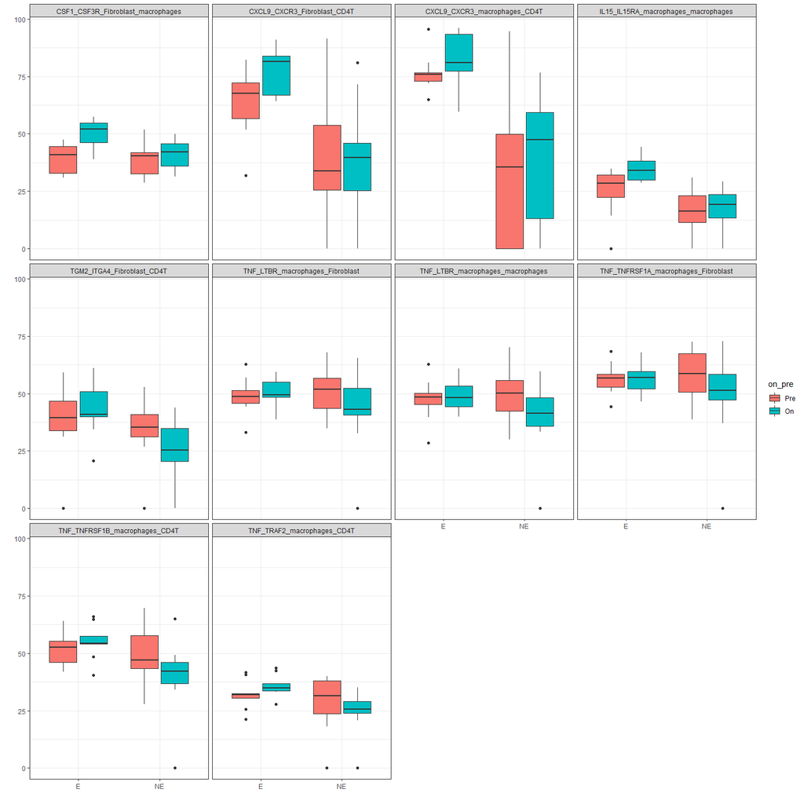

```r
p_lr_prod_change_boxplot = sample_data %>% mutate(patient = factor(patient, levels = order_patients)) %>%
    ggplot(aes(x = contrast, y = ligand_receptor_pb_prod, fill = on_pre, group = group)) +
    geom_boxplot() +
    facet_wrap(id~.) +
    theme_bw() +
    xlab("") + ylab("")

p_lr_prod_change_boxplot
```

These boxplots reflect what the DE model underlying MultiNicheNet infers: namely average group differences. However, they don’t show potential inter-sample heterogeneity. That’s why we will also create bubble and line plots in the following blocks of code.

### Bubble plots

Bubble Blot for E group

We will now visualize the On-vs-Pre absolute difference in pseudobulk ligand-receptor expression product in a bubble plot.

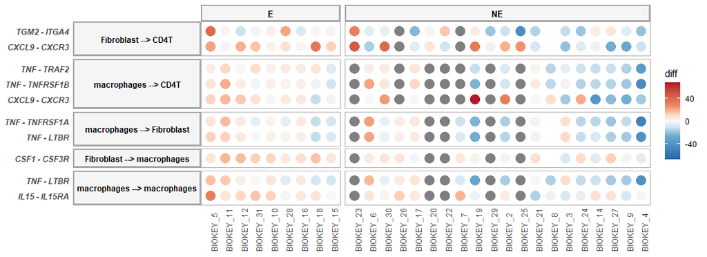

```r
max_diff = abs(sample_data$diff) %>% max(na.rm = TRUE)
custom_scale_color = scale_color_gradientn(colours = RColorBrewer::brewer.pal(n = 7,
        name = "RdBu") %>% rev(), values = c(0, 0.30, 0.425,
        0.5, 0.575, 0.70, 1), limits = c(-1 * max_diff, max_diff))

p_lr_prod_change = sample_data %>% mutate(patient = factor(patient, levels = order_patients)) %>%
    ggplot(aes(patient, lr_interaction, color = diff)) +
    geom_point(size = 5) +
    facet_grid(sender_receiver~contrast, scales = "free", space = "free", switch = "y") +
    theme_light() +
        theme(axis.ticks = element_blank(), axis.title = element_blank(),
            axis.text.y = element_text(face = "bold.italic",
                size = 9), axis.text.x = element_text(size = 9,
                angle = 90, hjust = 0), panel.grid.major = element_blank(),
            panel.grid.minor = element_blank(), panel.spacing.x = unit(0.4,
                "lines"), panel.spacing.y = unit(0.25,
                "lines"), strip.text.x.top = element_text(size = 10,
                color = "black", face = "bold", angle = 0),
            strip.text.y.left = element_text(size = 9, color = "black",
                face = "bold", angle = 0), strip.background = element_rect(color = "darkgrey",
                fill = "whitesmoke", size = 1.5, linetype = "solid")) +
    custom_scale_color +
    xlab("") + ylab("")
p_lr_prod_change
```

### Line plots

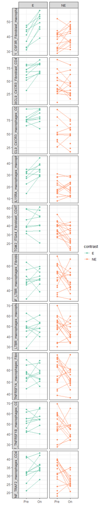

```r
line_plot = sample_data %>% filter(ligand_receptor_pb_prod != 0) %>%
    ggplot(aes(on_pre, ligand_receptor_pb_prod, group = patient, color = contrast)) +
    geom_point() + geom_line() +
    facet_grid(id~contrast, scales = "free", switch = "y") +
    theme_bw() +
    scale_color_brewer(palette = "Set2") +
    xlab("") + ylab("")
line_plot
```